# Data AnalysisHb17052016

## H4

> The share of subjects converging to the recommended, respectively defaulted payment-values, relative to the political-characteristic condition, is higher for subjects with same party preferences, and lower for subjects with different party preferences. **Hypothesis is phrased wrongly.**

> The share of subjects converging to the recommended, respectively defaulted payment-values in treatment groups that encounter a partisan source, is higher for those with the same party preferences, and lower for subjects with different party preferences.

```r
table(df$green, df$RecParvsDefPar)
```

```
##
##             RecPar DefPar
##   Not green     28     23
##   Green          2     11
```

```r
chisq.test(table(df$green, df$RecParvsDefPar))
```

```
##
##  Pearson's Chi-squared test with Yates' continuity correction
##
## data:  table(df$green, df$RecParvsDefPar)
## X-squared = 5.0064, df = 1, p-value = 0.02525
```

*The Chi² test suggests that there is a significant difference of green subjects in RecPar and DefPar treatments. Judged by the table, there are significantly less green subjects in the RecPar treatment, copared to the DefPar treatment. This will have to be accounted for in the test and is suboptimal.*

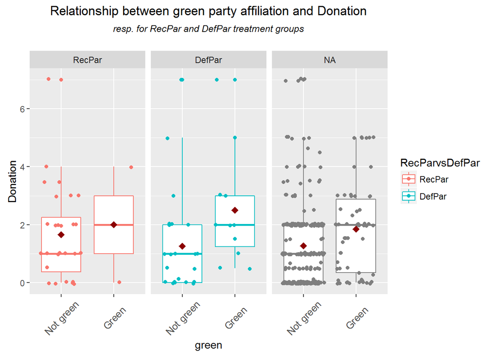

```
##
##  Wilcoxon rank sum test with continuity correction
##
## data:  df$Donation[df$treatment == "RecPar"] by df$green[df$treatment == "RecPar"]
## W = 26, p-value = 0.4494
## alternative hypothesis: true location shift is less than 0
```

```
##
##  Wilcoxon rank sum test with continuity correction
##
## data:  df$Donation[df$treatment == "DefPar"] by df$green[df$treatment == "DefPar"]
## W = 64.5, p-value = 0.01079
## alternative hypothesis: true location shift is less than 0
```

```
##
## t test of coefficients:
##
##                                 Estimate Std. Error t value Pr(>|t|)
## (Intercept)                      1.66071    0.30977  5.3612 1.39e-06 ***
## RecParvsDefParDefPar            -0.39550    0.48213 -0.8203   0.4153
## greenGreen                       0.33929    1.49308  0.2272   0.8210
## RecParvsDefParDefPar:greenGreen  0.89550    1.64608  0.5440   0.5884
## ---
## Signif. codes:  0 '***' 0.001 '**' 0.01 '*' 0.05 '.' 0.1 ' ' 1
```

**Does this account for the fact that generally green subjects give more (i.e. those in the other treatment groups thatn RecPar and DefPar)? Would I have to account for this by including the other groups that are different from RecPar and DefPar (which are so far excluded as NAs)?**

# Further Statistics and Tests

Since from now on we do not only test hypotheses that were stated before conducting the experiment, we can now freely vary the dependent variable and other variables.

## Compare observations that believe we cooperated with Julia Verlinden vs. those who don’t

### Variable: Donation amount

```
## group: Ja
##   vars   n mean   sd median trimmed  mad min max range skew kurtosis  se
## 1    1 153 1.32 1.27      1    1.16 1.48   0   5     5 0.88     0.23 0.1
## --------------------------------------------------------
## group: Nein
##   vars   n mean   sd median trimmed  mad min max range skew kurtosis   se
## 1    1 109 1.73 1.79    1.5    1.45 1.48   0   7     7  1.3     1.38 0.17
```

```
##
##  Wilcoxon rank sum test with continuity correction
##
## data:  df$Donation by df$believe2
## W = 7631.5, p-value = 0.2333
## alternative hypothesis: true location shift is not equal to 0
```

*Based on the two-sided Wilcoxon test we can not confidently reject the null hypothesis of equal median locations of donation amounts between those who believe we cooperated with Julia Verlinden and those who do not believe us.*

## Decision to donate for subjects seeing a recommendation vs. subjects seeing a default, with non-political source-information

```
##
##               Non-political/partisan Rec Non-political/partisan Def
##   Not donated                         31                         37
##   Donated                             66                         64
```

```
##
##  Pearson's Chi-squared test with Yates' continuity correction
##
## data:  table(df$Donated, df$RecvsDefNonPolPar)
## X-squared = 0.29465, df = 1, p-value = 0.5873
```

*The Chi²-Test is not significant. This implies that the decision whether or not to contribute anything vs. nothing is not dependent on whether the subjects encountered a non-political or non-partisan recommendation or a respective default value.*

## Decision to donate for subjects seeing an intervention without source-information vs. some source-information

```
##
##               No Source Some Source Control
##   Not donated        27          69      13
##   Donated            38         189      18
```

```
##
##  Pearson's Chi-squared test
##
## data:  table(df$Donated, df$NosvsSome)
## X-squared = 7.3127, df = 2, p-value = 0.02583
```

*The Chi² test is significant (p < .1). This implies that the decision whether or not to contribute or not depends on whether or not some source-information vs. no source-information is provided.*

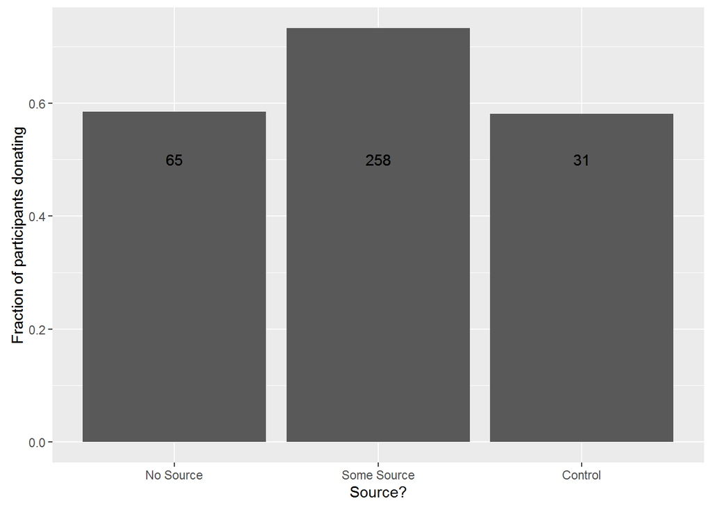

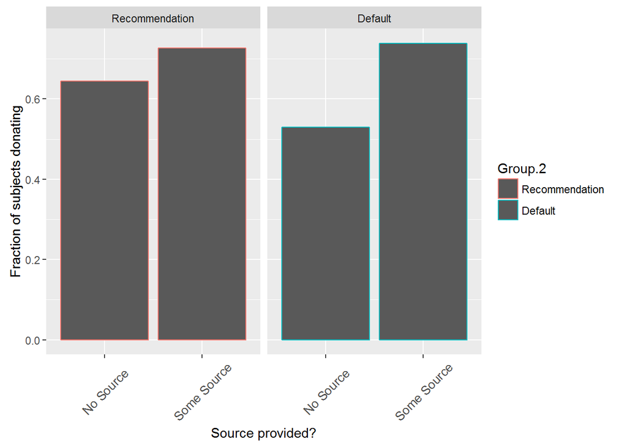

```
##
## z test of coefficients:
##
##                        Estimate Std. Error z value Pr(>|z|)
## (Intercept)            0.376871   0.281940  1.3367  0.18132
## NosvsSomeDSome Source  0.664771   0.289306  2.2978  0.02157 *
## RecvsDefDDef          -0.066962   0.246880 -0.2712  0.78621
## ---
## Signif. codes:  0 '***' 0.001 '**' 0.01 '*' 0.05 '.' 0.1 ' ' 1
```

```
##
## z test of coefficients:
##
##                                    Estimate Std. Error z value Pr(>|z|)
## (Intercept)                         0.59784    0.37772  1.5827   0.1135
## NosvsSomeDSome Source               0.37941    0.42719  0.8882   0.3745
## RecvsDefDDef                       -0.48005    0.51207 -0.9375   0.3485
## NosvsSomeDSome Source:RecvsDefDDef  0.54079    0.58511  0.9242   0.3554
```

```
##
## z test of coefficients:
##
##                                       Estimate Std. Error z value Pr(>|z|)
## (Intercept)                            0.59784    0.38133  1.5678   0.1169
## SourcetypeNameAndPicture               0.23507    0.54173  0.4339   0.6643
## SourcetypeKnowledgeable                0.23507    0.54173  0.4339   0.6643
## SourcetypePolitical                    0.67513    0.57802  1.1680   0.2428
## SourcetypePartisan                     0.41376    0.56684  0.7299   0.4654
## RecvsDefDDef                          -0.48005    0.51695 -0.9286   0.3531
## SourcetypeNameAndPicture:RecvsDefDDef  0.62797    0.75694  0.8296   0.4068
## SourcetypeKnowledgeable:RecvsDefDDef   0.25328    0.74041  0.3421   0.7323
## SourcetypePolitical:RecvsDefDDef       0.77570    0.83984  0.9236   0.3557
## SourcetypePartisan:RecvsDefDDef        0.64711    0.78219  0.8273   0.4081
```

*In the robust logistic regression controlling for intervention type, the estimator for the provision of any source-information is also statistically significant and positive (Excluding the control group). However, in the second robust logistic regression that treats both variables as an interaction, neither main effects nor interaction effect is significant. The same is the case when disaggregating sourcetype.*

**I need to understand which of both treatments of both factor variables is adequate, i.e. how both interpretations differ. That is very important.**

## Graphs in order to see potential interactions

### Political/partisan vs. non-political/partisan source information

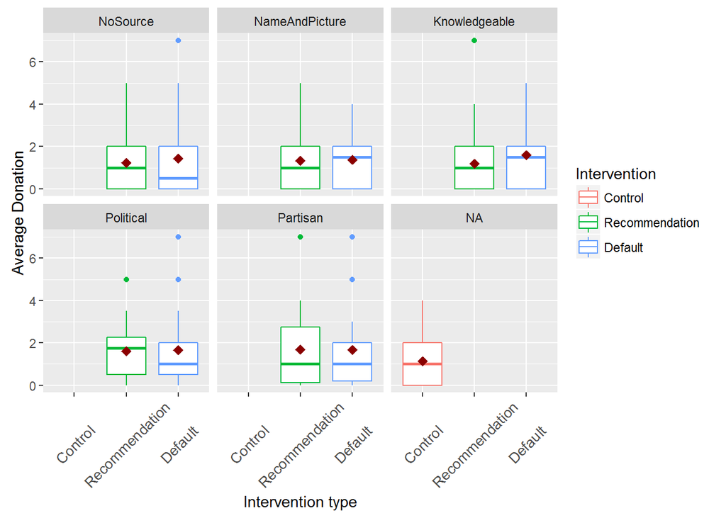

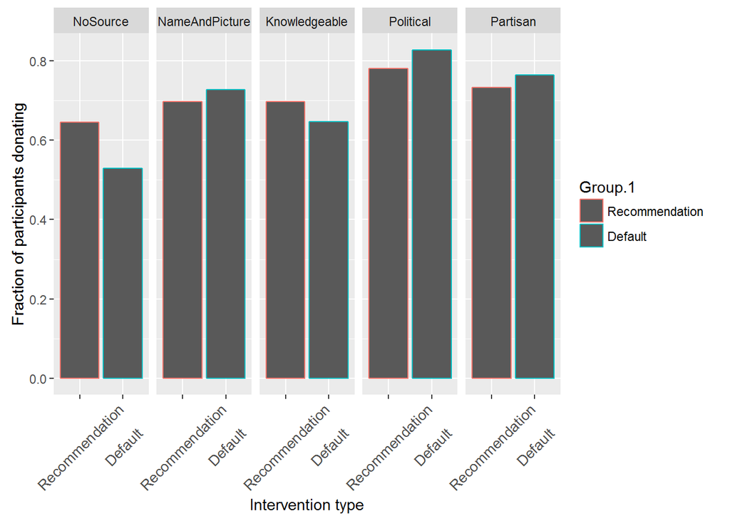

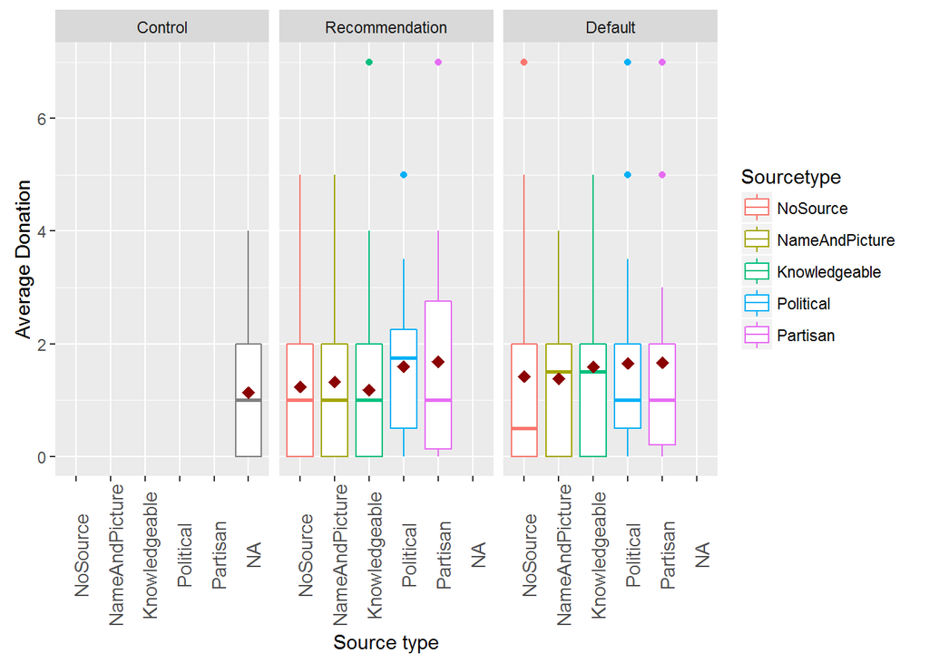

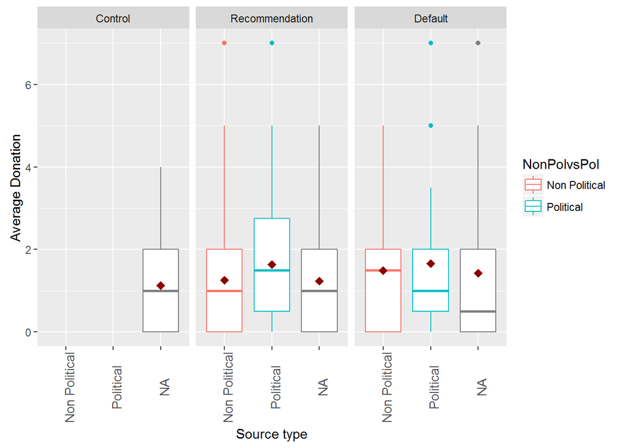

```
## group: Non Political
##   vars   n mean   sd median trimmed  mad min max range skew kurtosis   se
## 1    1 133 1.37 1.41      1    1.16 1.48   0   7     7 1.15     1.35 0.12
## --------------------------------------------------------
## group: Political
##   vars   n mean   sd median trimmed  mad min max range skew kurtosis   se
## 1    1 125 1.65 1.62      1     1.4 1.48   0   7     7 1.36     1.93 0.15
```

```
##
##  Wilcoxon rank sum test with continuity correction
##
## data:  df$Donation by df$NonPolvsPol
## W = 7533, p-value = 0.09242
## alternative hypothesis: true location shift is less than 0
```

```
##
## t test of coefficients:
##
##                                          Estimate Std. Error t value
## (Intercept)                               1.25303    0.17014  7.3646
## NonPolvsPolPolitical                      0.38729    0.25168  1.5388
## InterventionDefault                       0.23354    0.24489  0.9536
## NonPolvsPolPolitical:InterventionDefault -0.21354    0.38053 -0.5612
##                                           Pr(>|t|)
## (Intercept)                              2.479e-12 ***
## NonPolvsPolPolitical                        0.1251
## InterventionDefault                         0.3412
## NonPolvsPolPolitical:InterventionDefault    0.5752
## ---
## Signif. codes:  0 '***' 0.001 '**' 0.01 '*' 0.05 '.' 0.1 ' ' 1
```

*This suggests (visually) that providing information about political/partisan aspects of the source has an impact for average contributions for Recommendations, but not for Defaults. Only looking at the median, providing information about political source characteristics might even be beneficial for recommendations and counter-beneficial for defaults. Further investigation with Wilcoxon Test and linear OLS-regression finds no significant effects.*

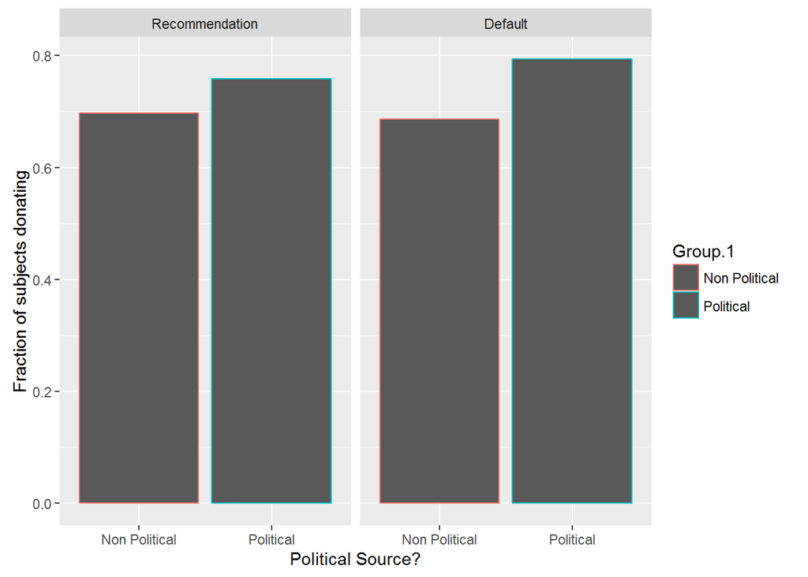

```r
m <- aggregate(df$Donatedm, list(df$NonPolvsPol, df$Intervention), sum)
m$n <- aggregate(df$Donatedm, list(df$NonPolvsPol, df$Intervention), length)[3]
ggplot(data = m, aes(x = Group.1, y = x/n, colour = Group.1)) +
  facet_grid(~Group.2) +
  geom_bar(stat = "identity") +
  xlab("Political Source?") +
  ylab("Fraction of subjects donating")
```

*There does not seem to be anything of interest here.*

### No source vs. no political source vs. political source

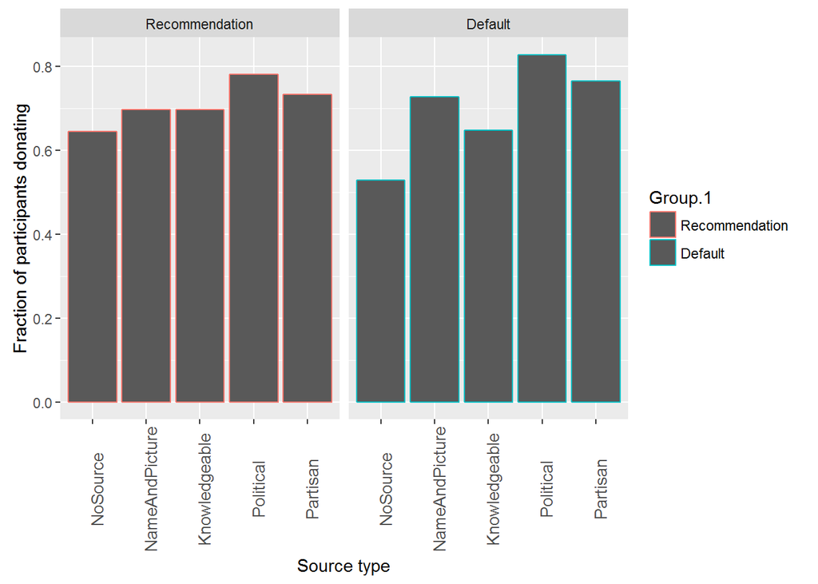

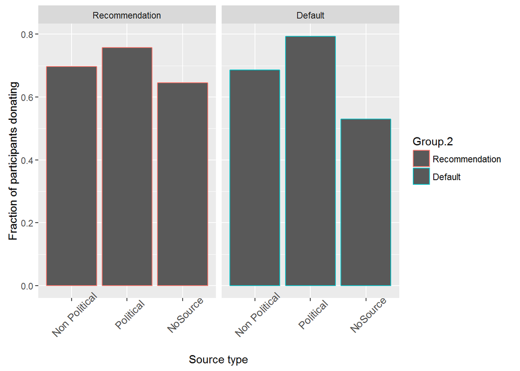

```
##
## z test of coefficients:
##
##                                   Estimate Std. Error z value Pr(>|z|)
## (Intercept)                        0.83291    0.27037  3.0807 0.002065 **
## NonPolvsPolAPolitical              0.30919    0.40337  0.7665 0.443368
## NonPolvsPolANoSource              -0.23507    0.46548 -0.5050 0.613553
## RecvsDefDef                       -0.04879    0.37917 -0.1287 0.897613
## NonPolvsPolAPolitical:RecvsDefDef  0.25377    0.57631  0.4403 0.659698
## NonPolvsPolANoSource:RecvsDefDef  -0.43126    0.63846 -0.6755 0.499376
## ---
## Signif. codes:  0 '***' 0.001 '**' 0.01 '*' 0.05 '.' 0.1 ' ' 1
```

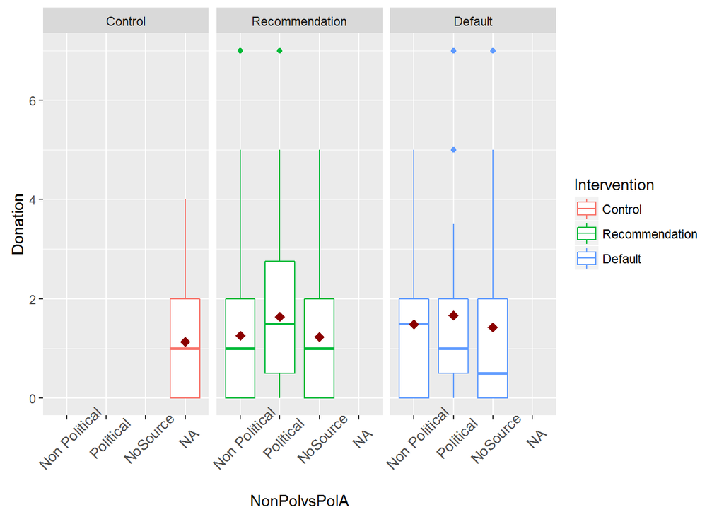

```
##
##  Kruskal-Wallis rank sum test
##
## data:  df$Donation[df$Intervention == "Recommendation"] by df$NonPolvsPolA[df$Intervention == "Recommendation"]
## Kruskal-Wallis chi-squared = 3.3912, df = 2, p-value = 0.1835
```

```
##
##  Kruskal-Wallis rank sum test
##
## data:  df$Donation[df$Intervention == "Default"] by df$NonPolvsPolA[df$Intervention == "Default"]
## Kruskal-Wallis chi-squared = 2.7509, df = 2, p-value = 0.2527
```

*The logistic regression does not produce any significant predictors. Neither do the Kruskal Wallis tests for the respective interventions.*

# Gender differences

```
##
##  Pearson's Chi-squared test
##
## data:  table(factor(dfsub$gender), dfsub$treatment)
## X-squared = 7.8565, df = 10, p-value = 0.6429
```

```
##
## z test of coefficients:
##
##                 Estimate Std. Error z value Pr(>|z|)
## (Intercept)      0.40547    0.37868  1.0707   0.2843
## treatmentRecNos  0.14108    0.53999  0.2613   0.7939
## treatmentDefNos -0.52325    0.51506 -1.0159   0.3097
## treatmentRecNap -0.28030    0.52245 -0.5365   0.5916
## treatmentDefNap  0.42744    0.53993  0.7917   0.4286
## treatmentRecPol  0.10536    0.53015  0.1987   0.8425
## treatmentDefPol  0.55962    0.56711  0.9868   0.3237
## treatmentRecPar -0.13720    0.53249 -0.2577   0.7967
## treatmentDefPar -0.16908    0.51630 -0.3275   0.7433
## treatmentRecKno  0.24116    0.53518  0.4506   0.6523
## treatmentDefKno -0.28768    0.51506 -0.5585   0.5765
```

*Gender is not significantly differently represented along tratments*

## Average donation gender differences (by treatment)

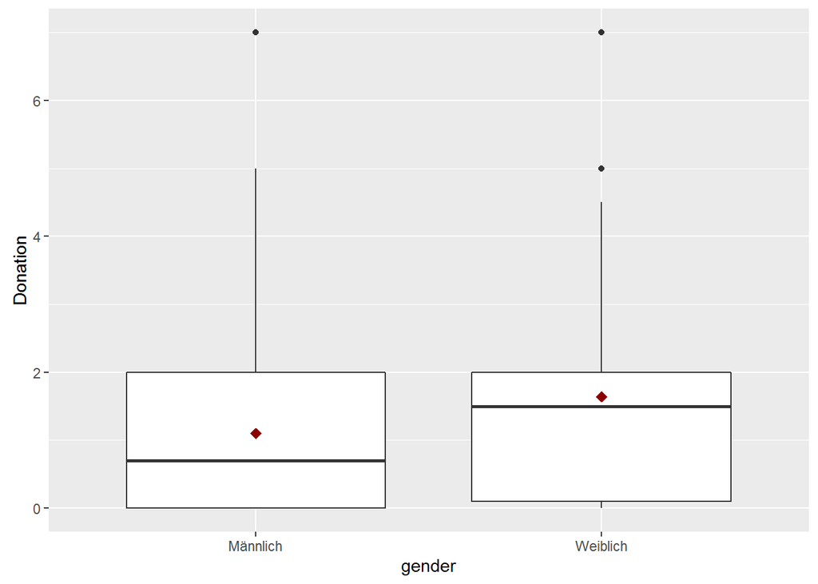

```
##
##  Wilcoxon rank sum test with continuity correction
##
## data:  dfsub$Donation by dfsub$gender
## W = 11246, p-value = 0.0001193
## alternative hypothesis: true location shift is not equal to 0
```

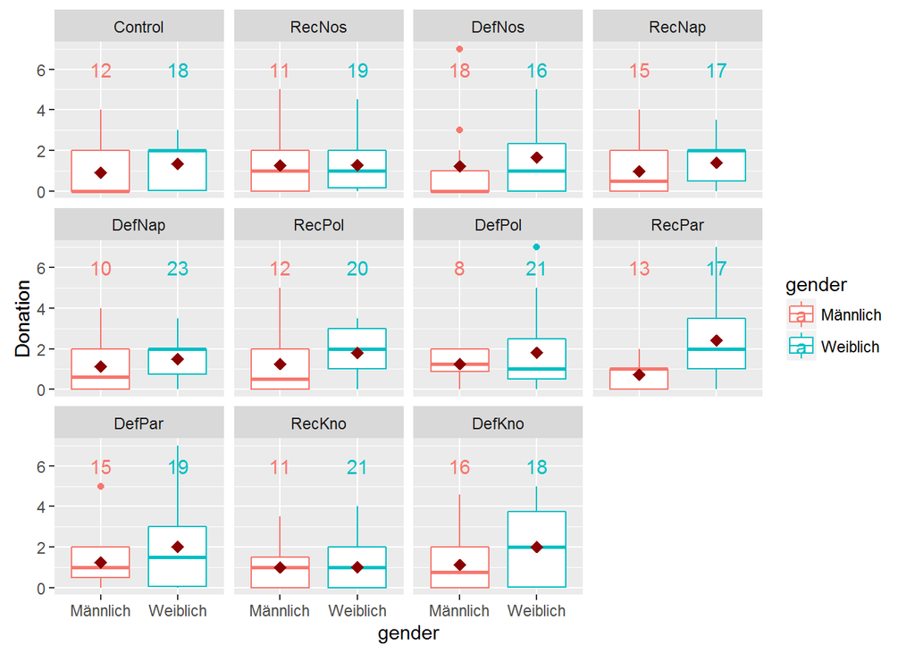

```
##
##  Kruskal-Wallis rank sum test
##
## data:  df$Donation[df$gender == "Weiblich"] by df$treatment[df$gender == "Weiblich"]
## Kruskal-Wallis chi-squared = 10.783, df = 10, p-value = 0.3746
```

```
##
##  Kruskal-Wallis rank sum test
##
## data:  df$Donation[df$gender == "Männlich"] by df$treatment[df$gender == "Männlich"]
## Kruskal-Wallis chi-squared = 3.978, df = 10, p-value = 0.9483
```

```
##
## t test of coefficients:
##
##                                                        Estimate Std. Error
## (Intercept)                                           1.2727273  0.4617067
## RecvsDefDDef                                         -0.0505051  0.7060991
## SourcetypeNameAndPicture                             -0.2993939  0.5551772
## SourcetypeKnowledgeable                              -0.2727273  0.5686527
## SourcetypePolitical                                  -0.0227273  0.6470924
## SourcetypePartisan                                   -0.5419580  0.5029761
## genderWeiblich                                        0.0062201  0.5560907
## RecvsDefDDef:SourcetypeNameAndPicture                 0.1971717  0.8754324
## RecvsDefDDef:SourcetypeKnowledgeable                  0.1817551  0.8466573
## RecvsDefDDef:SourcetypePolitical                      0.0505051  0.8779511
## RecvsDefDDef:SourcetypePartisan                       0.5530692  0.8044307
## RecvsDefDDef:genderWeiblich                           0.4215577  0.9076378
## SourcetypeNameAndPicture:genderWeiblich               0.4322113  0.6890911
## SourcetypeKnowledgeable:genderWeiblich               -0.0014582  0.6871545
## SourcetypePolitical:genderWeiblich                    0.5537799  0.7558927
## SourcetypePartisan:genderWeiblich                     1.6747754  0.7345500
## RecvsDefDDef:SourcetypeNameAndPicture:genderWeiblich -0.4930325  1.0999332
## RecvsDefDDef:SourcetypeKnowledgeable:genderWeiblich   0.4479860  1.1413056
## RecvsDefDDef:SourcetypePolitical:genderWeiblich      -0.4220339  1.1531497
## RecvsDefDDef:SourcetypePartisan:genderWeiblich       -1.3306233  1.1954520
##                                                      t value Pr(>|t|)
## (Intercept)                                           2.7566 0.006199 **
## RecvsDefDDef                                         -0.0715 0.943026
## SourcetypeNameAndPicture                             -0.5393 0.590096
## SourcetypeKnowledgeable                              -0.4796 0.631859
## SourcetypePolitical                                  -0.0351 0.972006
## SourcetypePartisan                                   -1.0775 0.282121
## genderWeiblich                                        0.0112 0.991083
## RecvsDefDDef:SourcetypeNameAndPicture                 0.2252 0.821955
## RecvsDefDDef:SourcetypeKnowledgeable                  0.2147 0.830168
## RecvsDefDDef:SourcetypePolitical                      0.0575 0.954164
## RecvsDefDDef:SourcetypePartisan                       0.6875 0.492281
## RecvsDefDDef:genderWeiblich                           0.4645 0.642658
## SourcetypeNameAndPicture:genderWeiblich               0.6272 0.530993
## SourcetypeKnowledgeable:genderWeiblich               -0.0021 0.998308
## SourcetypePolitical:genderWeiblich                    0.7326 0.464364
## SourcetypePartisan:genderWeiblich                     2.2800 0.023309 *
## RecvsDefDDef:SourcetypeNameAndPicture:genderWeiblich -0.4482 0.654305
## RecvsDefDDef:SourcetypeKnowledgeable:genderWeiblich   0.3925 0.694952
## RecvsDefDDef:SourcetypePolitical:genderWeiblich      -0.3660 0.714635
## RecvsDefDDef:SourcetypePartisan:genderWeiblich       -1.1131 0.266569
## ---
## Signif. codes:  0 '***' 0.001 '**' 0.01 '*' 0.05 '.' 0.1 ' ' 1
```

### Extensive margin (by treatment)

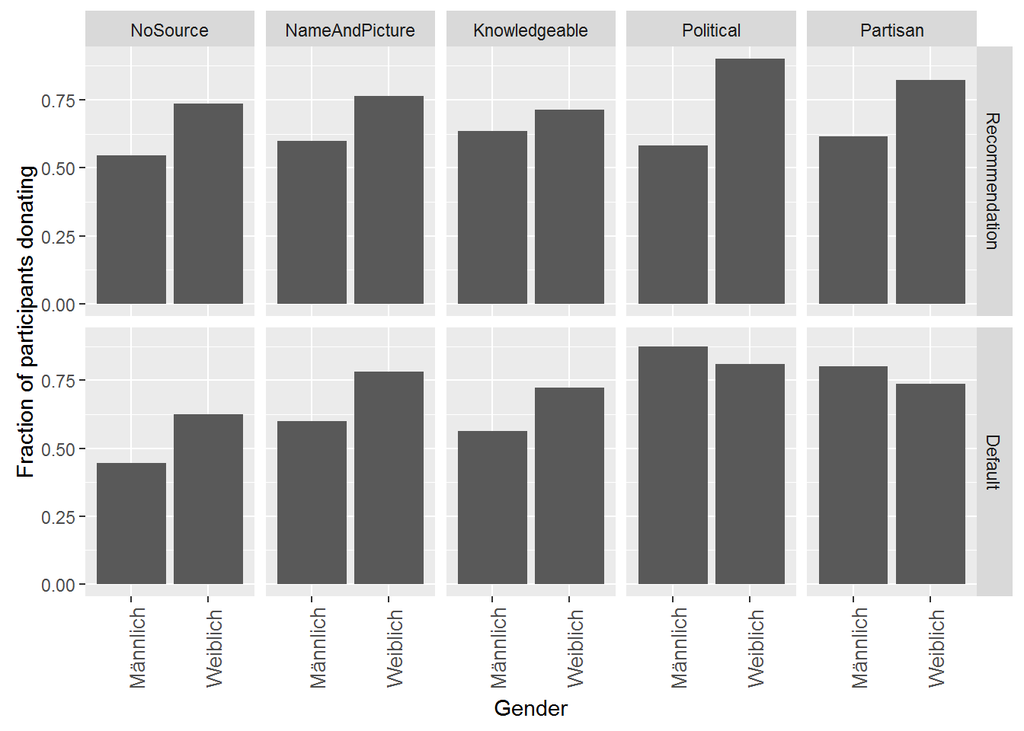

```
##
##  Pearson's Chi-squared test with Yates' continuity correction
##
## data:  table(dfsub$Donated, factor(dfsub$gender))
## X-squared = 10.039, df = 1, p-value = 0.001533
```

```
##
## z test of coefficients:
##
##                  Estimate Std. Error z value Pr(>|z|)
## (Intercept)     -0.020696   0.402784 -0.0514 0.959021
## treatmentRecNos  0.271197   0.547481  0.4954 0.620350
## treatmentDefNos -0.200359   0.518331 -0.3865 0.699092
## treatmentRecNap  0.446364   0.544708  0.8195 0.412526
## treatmentDefNap  0.517558   0.549597  0.9417 0.346344
## treatmentRecPol  0.872713   0.567000  1.5392 0.123761
## treatmentDefPol  1.096497   0.640256  1.7126 0.086788 .
## treatmentRecPar  0.649185   0.564333  1.1504 0.249997
## treatmentDefPar  0.826367   0.574446  1.4385 0.150279
## treatmentRecKno  0.351673   0.548225  0.6415 0.521214
## treatmentDefKno  0.259974   0.529050  0.4914 0.623145
## genderWeiblich   0.729405   0.245218  2.9745 0.002934 **
## ---
## Signif. codes:  0 '***' 0.001 '**' 0.01 '*' 0.05 '.' 0.1 ' ' 1
```

```
##
## z test of coefficients:
##
##                                       Estimate Std. Error z value Pr(>|z|)
## (Intercept)                           0.285927   0.425240  0.6724 0.501335
## RecvsDefDef                          -0.479177   0.532268 -0.9003 0.367985
## SourcetypeNameAndPicture              0.168028   0.557799  0.3012 0.763235
## SourcetypeKnowledgeable               0.081571   0.560824  0.1454 0.884357
## SourcetypePolitical                   0.598446   0.580290  1.0313 0.302405
## SourcetypePartisan                    0.372131   0.577073  0.6449 0.519018
## genderWeiblich                        0.668743   0.258073  2.5913 0.009562
## RecvsDefDef:SourcetypeNameAndPicture  0.560556   0.775281  0.7230 0.469658
## RecvsDefDef:SourcetypeKnowledgeable   0.380000   0.758981  0.5007 0.616603
## RecvsDefDef:SourcetypePolitical       0.708869   0.850983  0.8330 0.404845
## RecvsDefDef:SourcetypePartisan        0.655172   0.799775  0.8192 0.412675
##
## (Intercept)
## RecvsDefDef
## SourcetypeNameAndPicture
## SourcetypeKnowledgeable
## SourcetypePolitical
## SourcetypePartisan
## genderWeiblich                       **
## RecvsDefDef:SourcetypeNameAndPicture
## RecvsDefDef:SourcetypeKnowledgeable
## RecvsDefDef:SourcetypePolitical
## RecvsDefDef:SourcetypePartisan
## ---
## Signif. codes:  0 '***' 0.001 '**' 0.01 '*' 0.05 '.' 0.1 ' ' 1
```

## Gender differences (by Intervention type)

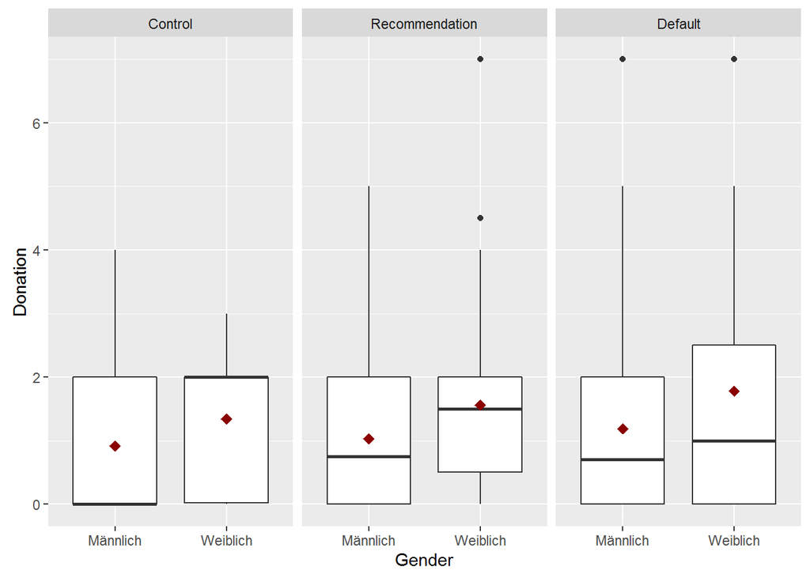

## Gender differences (by Source type)

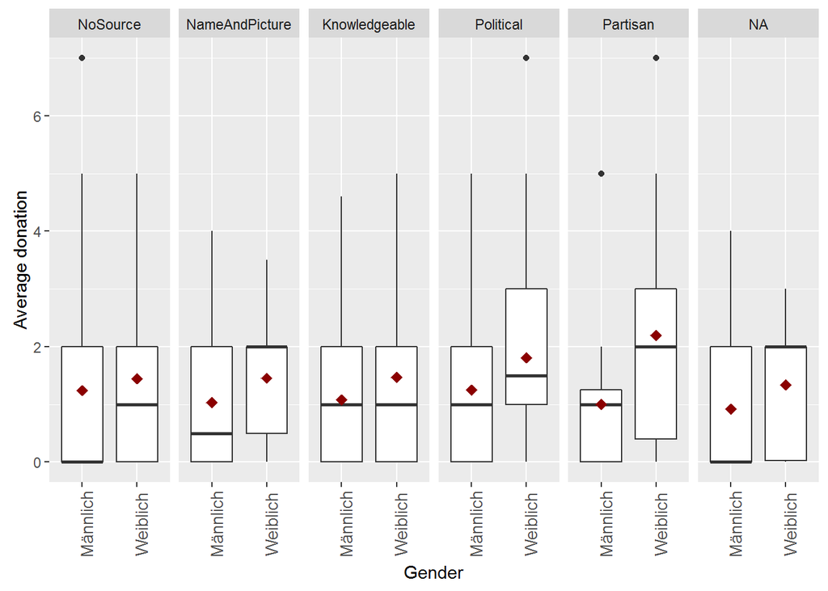

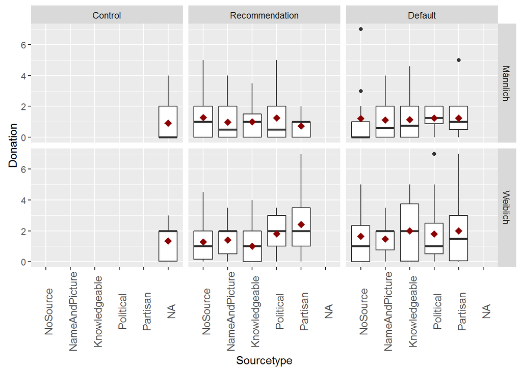

- *The second graph shows that there appears to be no effect of providing source information for men, neither for recommendations, nor for defaults.*
- *There appears to be a minor effect of providing source information for women, when the intervention type is a recommendation. There, providing information about the political/partisan characteristics of the source increases median and mean donations.*

### Does this effect pick up in extensive margin?

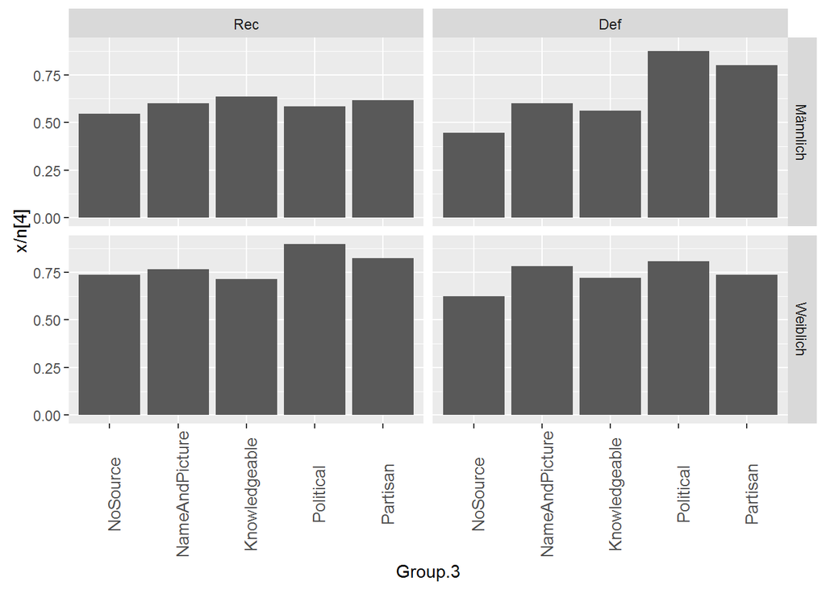

```
##
##  Kruskal-Wallis rank sum test
##
## data:  dfsub$Donation[dfsub$gender == "Weiblich" & dfsub$Intervention == "Recommendation"] by dfsub$Sourcetype[dfsub$gender == "Weiblich" & dfsub$Intervention == "Recommendation"]
## Kruskal-Wallis chi-squared = 10.733, df = 4, p-value = 0.02973
```

*Based on the Kruskal Wallis test, average Donations of women seeing a recommendation differ significantly for the different sourcetypes.*

```
##
##  Kruskal-Wallis rank sum test
##
## data:  dfsub$Donation[dfsub$gender == "Weiblich" & dfsub$Intervention == "Default"] by dfsub$Sourcetype[dfsub$gender == "Weiblich" & dfsub$Intervention == "Default"]
## Kruskal-Wallis chi-squared = 0.61934, df = 4, p-value = 0.9609
```

```
##
##  Kruskal-Wallis rank sum test
##
## data:  dfsub$Donation[dfsub$gender == "Männlich" & dfsub$Intervention == "Recommendation"] by dfsub$Sourcetype[dfsub$gender == "Männlich" & dfsub$Intervention == "Recommendation"]
## Kruskal-Wallis chi-squared = 0.40054, df = 4, p-value = 0.9824
```

```
##
##  Kruskal-Wallis rank sum test
##
## data:  dfsub$Donation[dfsub$gender == "Männlich" & dfsub$Intervention == "Default"] by dfsub$Sourcetype[dfsub$gender == "Männlich" & dfsub$Intervention == "Default"]
## Kruskal-Wallis chi-squared = 2.8933, df = 4, p-value = 0.5758
```

*Neither for women seeing a default, nor for men seeing either intervention type, is there an effect of sourcetype on average donations.*

```
##
##  Kruskal-Wallis rank sum test
##
## data:  dfsub$Donation[dfsub$gender == "Weiblich" & dfsub$Intervention == "Recommendation"] by dfsub$NonPolvsPolA[dfsub$gender == "Weiblich" & dfsub$Intervention == "Recommendation"]
## Kruskal-Wallis chi-squared = 8.9371, df = 2, p-value = 0.01146
```

```
##
## t test of coefficients:
##
##                                                    Estimate Std. Error
## (Intercept)                                       0.9846154  0.2229574
## genderWeiblich                                    0.2022267  0.2829836
## RecvsDefDDef                                      0.1423077  0.3377050
## NonPolvsPolPolitical                             -0.0046154  0.3297555
## genderWeiblich:RecvsDefDDef                       0.3854843  0.4464933
## genderWeiblich:NonPolvsPolPolitical               0.9042598  0.4433252
## RecvsDefDDef:NonPolvsPolPolitical                 0.1168227  0.4750076
## genderWeiblich:RecvsDefDDef:NonPolvsPolPolitical -0.8286013  0.6884801
##                                                  t value  Pr(>|t|)
## (Intercept)                                       4.4162 1.501e-05 ***
## genderWeiblich                                    0.7146   0.47551
## RecvsDefDDef                                      0.4214   0.67383
## NonPolvsPolPolitical                             -0.0140   0.98884
## genderWeiblich:RecvsDefDDef                       0.8634   0.38877
## genderWeiblich:NonPolvsPolPolitical               2.0397   0.04244 *
## RecvsDefDDef:NonPolvsPolPolitical                 0.2459   0.80593
## genderWeiblich:RecvsDefDDef:NonPolvsPolPolitical -1.2035   0.22992
## ---
## Signif. codes:  0 '***' 0.001 '**' 0.01 '*' 0.05 '.' 0.1 ' ' 1
```

- *Based on the Kruskal Wallis test, there is a significant difference of donations between women seeing a recommendation by non-political/partisan vs. policial/partisan sources. This is a more aggregated effect than the effect before. Before, we saw that this effect is significant primarily because of the donations in the recommendation by partisan source groups (which has, by the way, 17 observations, i.e. there are 17 womeon that see a recommendation by a partisan source).*

## Gender and Reactance interaction per treatment

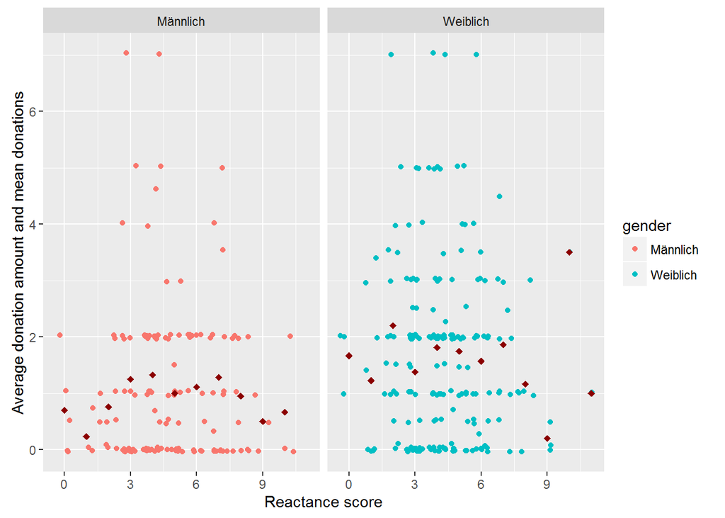

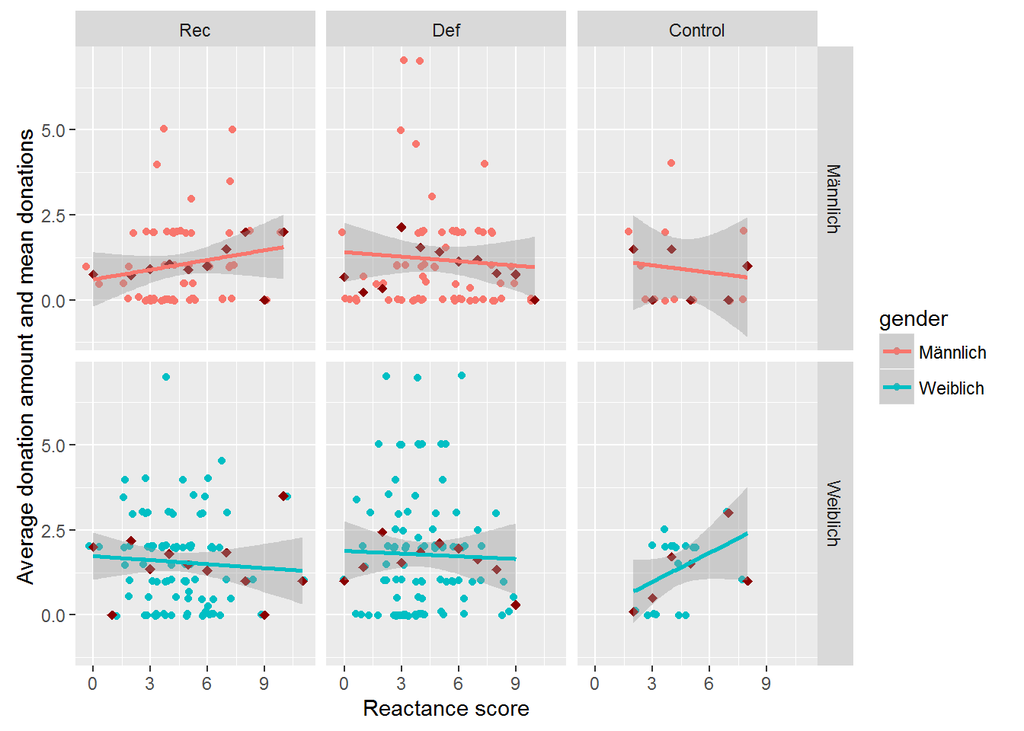

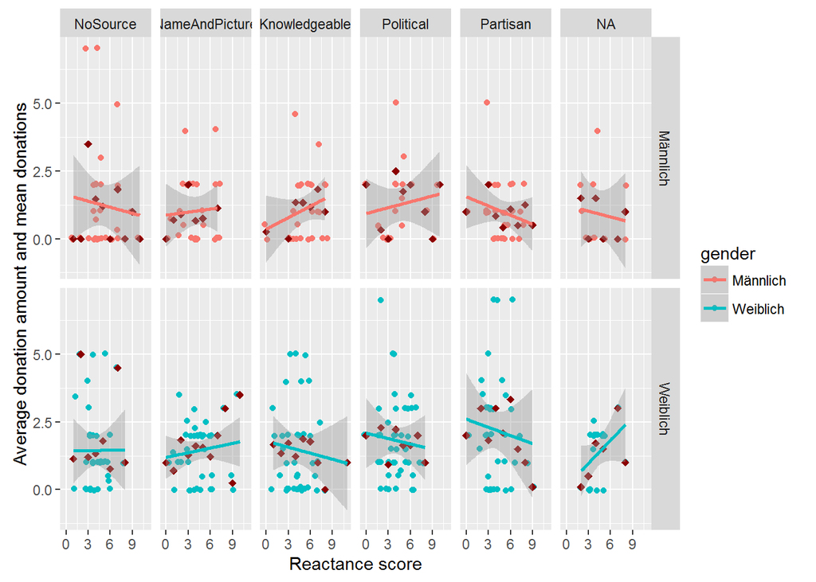

# Including only “believers” in Julia Verlinden

## First check if whether subjects believe we cooperated depends on treatment

```
##
##  Pearson's Chi-squared test
##
## data:  table(dfbelA$believe2, dfbelA$treatment)
## X-squared = 12.544, df = 7, p-value = 0.08403
```

```
##
## z test of coefficients:
##
##                 Estimate Std. Error z value Pr(>|z|)
## (Intercept)      0.25131    0.36205  0.6941  0.48759
## treatmentDefNap  0.72951    0.53739  1.3575  0.17462
## treatmentRecPol -0.37648    0.51051 -0.7375  0.46084
## treatmentDefPol -0.18232    0.52310 -0.3485  0.72743
## treatmentRecPar -0.11778    0.51897 -0.2270  0.82046
## treatmentDefPar -0.36910    0.50294 -0.7339  0.46302
## treatmentRecKno  1.02165    0.56554  1.8065  0.07084 .
## treatmentDefKno  0.22826    0.50955  0.4480  0.65418
## ---
## Signif. codes:  0 '***' 0.001 '**' 0.01 '*' 0.05 '.' 0.1 ' ' 1
```

```
##
## z test of coefficients:
##
##                                             Estimate Std. Error z value
## (Intercept)                                  0.25131    0.36205  0.6941
## SourcetypeKnowledgeable                      1.02165    0.56554  1.8065
## SourcetypePolitical                         -0.37648    0.51051 -0.7375
## SourcetypePartisan                          -0.11778    0.51897 -0.2270
## InterventionDefault                          0.72951    0.53739  1.3575
## SourcetypeKnowledgeable:InterventionDefault -1.52291    0.77853 -1.9561
## SourcetypePolitical:InterventionDefault     -0.53536    0.74892 -0.7148
## SourcetypePartisan:InterventionDefault      -0.98083    0.74088 -1.3239
##                                             Pr(>|z|)
## (Intercept)                                  0.48759
## SourcetypeKnowledgeable                      0.07084 .
## SourcetypePolitical                          0.46084
## SourcetypePartisan                           0.82046
## InterventionDefault                          0.17462
## SourcetypeKnowledgeable:InterventionDefault  0.05045 .
## SourcetypePolitical:InterventionDefault      0.47470
## SourcetypePartisan:InterventionDefault       0.18554
## ---
## Signif. codes:  0 '***' 0.001 '**' 0.01 '*' 0.05 '.' 0.1 ' ' 1
```

- *According to the Chi²-Test, there is no significant difference in the number of people believing we cooperated with Julia Verlinden based on the different treatments that were asked this question.*
- *Based on the first robust logistic regression, subjects are more likely to believe the cooperation when they are in the Recommendation Knowledgeable treatment.*
- *Based on the second robust logistic regression, subjects are more likely to believe the cooperation when they see a knowledgeable source. However, this positive effect is diminished when being confronted with defaults rather than recommendations. Both effects are only significant at the 10% significance level.*

## What explains the probability that people believe we cooperated with Julia?

```
##
##  Pearson's Chi-squared test with simulated p-value (based on 2000
##  replicates)
##
## data:  table(dfbelA$believe2, dfbelA$gender)
## X-squared = 0.13376, df = NA, p-value = 0.7911
```

```
##
## z test of coefficients:
##
##                 Estimate Std. Error z value Pr(>|z|)
## (Intercept)      0.33110    0.38694  0.8557  0.39217
## genderWeiblich  -0.14952    0.27163 -0.5505  0.58201
## treatmentDefNap  0.75502    0.53832  1.4026  0.16075
## treatmentRecPol -0.36296    0.51219 -0.7086  0.47854
## treatmentDefPol -0.15373    0.52668 -0.2919  0.77037
## treatmentRecPar -0.11265    0.52210 -0.2158  0.82917
## treatmentDefPar -0.36548    0.50218 -0.7278  0.46674
## treatmentRecKno  1.04141    0.56294  1.8499  0.06432 .
## treatmentDefKno  0.22829    0.50960  0.4480  0.65417
## ---
## Signif. codes:  0 '***' 0.001 '**' 0.01 '*' 0.05 '.' 0.1 ' ' 1
```

```
##
##  Pearson's Chi-squared test with simulated p-value (based on 2000
##  replicates)
##
## data:  table(dfbelA$believe2, dfbelA$party)
## X-squared = 1.7624, df = NA, p-value = 0.989
```

```
##
## z test of coefficients:
##
##                                     Estimate Std. Error z value Pr(>|z|)
## (Intercept)                         -0.21043    0.85943 -0.2449  0.80657
## partyAndere                          0.35639    0.97234  0.3665  0.71397
## partyBündnis90/Grüne                 0.38466    0.86106  0.4467  0.65507
## partyCDU/CSU                         0.20828    0.88567  0.2352  0.81408
## partyDie Linke                       0.50038    0.88607  0.5647  0.57227
## partyFDP                             0.77889    1.13165  0.6883  0.49128
## partyKeine (Nichtwähler)             0.63433    0.91662  0.6920  0.48892
## partyKeine Angabe                    1.09421    1.51540  0.7221  0.47026
## partySPD                             0.62028    0.86597  0.7163  0.47382
## RecvsDefDef                          0.72001    0.55740  1.2917  0.19645
## SourcetypeKnowledgeable              1.08207    0.59482  1.8192  0.06889 .
## SourcetypePolitical                 -0.39537    0.53179 -0.7435  0.45720
## SourcetypePartisan                  -0.15024    0.53641 -0.2801  0.77941
## RecvsDefDef:SourcetypeKnowledgeable -1.58468    0.80767 -1.9621  0.04976 *
## RecvsDefDef:SourcetypePolitical     -0.53527    0.78369 -0.6830  0.49460
## RecvsDefDef:SourcetypePartisan      -0.91372    0.76007 -1.2022  0.22930
## ---
## Signif. codes:  0 '***' 0.001 '**' 0.01 '*' 0.05 '.' 0.1 ' ' 1
```

```
##
## z test of coefficients:
##
##                                      Estimate Std. Error z value Pr(>|z|)
## (Intercept)                          0.285396   0.482342  0.5917  0.55406
## Reactance                           -0.007268   0.067526 -0.1076  0.91429
## RecvsDefDef                          0.725446   0.538825  1.3463  0.17819
## SourcetypeKnowledgeable              1.021703   0.565865  1.8056  0.07099
## SourcetypePolitical                 -0.378315   0.512641 -0.7380  0.46053
## SourcetypePartisan                  -0.121576   0.521305 -0.2332  0.81560
## RecvsDefDef:SourcetypeKnowledgeable -1.518955   0.781546 -1.9435  0.05195
## RecvsDefDef:SourcetypePolitical     -0.534460   0.751072 -0.7116  0.47672
## RecvsDefDef:SourcetypePartisan      -0.973067   0.744252 -1.3074  0.19106
##
## (Intercept)
## Reactance
## RecvsDefDef
## SourcetypeKnowledgeable             .
## SourcetypePolitical
## SourcetypePartisan
## RecvsDefDef:SourcetypeKnowledgeable .
## RecvsDefDef:SourcetypePolitical
## RecvsDefDef:SourcetypePartisan
## ---
## Signif. codes:  0 '***' 0.001 '**' 0.01 '*' 0.05 '.' 0.1 ' ' 1
```

```
##
## z test of coefficients:
##
##                                     Estimate Std. Error z value Pr(>|z|)
## (Intercept)                          0.21959    0.36950  0.5943  0.55231
## demandEffectDDemEff                  0.14616    0.32775  0.4459  0.65564
## RecvsDefDef                          0.74835    0.53738  1.3926  0.16374
## SourcetypeKnowledgeable              1.00899    0.56632  1.7817  0.07480 .
## SourcetypePolitical                 -0.36766    0.50959 -0.7215  0.47061
## SourcetypePartisan                  -0.10060    0.52053 -0.1933  0.84676
## RecvsDefDef:SourcetypeKnowledgeable -1.54836    0.78018 -1.9846  0.04719 *
## RecvsDefDef:SourcetypePolitical     -0.56145    0.75032 -0.7483  0.45429
## RecvsDefDef:SourcetypePartisan      -1.02392    0.74664 -1.3714  0.17026
## ---
## Signif. codes:  0 '***' 0.001 '**' 0.01 '*' 0.05 '.' 0.1 ' ' 1
```

*Whether or not respondents believe us that we cooperated with Julia does not differ by* * *gender (Chi²Test with simulated p-values and robust logistic regression controlling for sourcetype and intervention type interactions),* * *party affiliation (Chi²Test with simulated p-values and robust logistic regression controlling for sourcetype and intervention type interactions),* * *Reactance score (treated as metric in a robust logistic regression controlling for sourcetype and intervention type interactions),* * *experiencing a demand effect (dummy in a robust logistic regression controlling for sourcetype and intervention type interactions).Ü*

```
##
##  Pearson's Chi-squared test with simulated p-value (based on 2000
##  replicates)
##
## data:  df$demandEffectD and df$treatment
## X-squared = 13.478, df = NA, p-value = 0.1904
```

```
##
## z test of coefficients:
##
##                                       Estimate Std. Error z value Pr(>|z|)
## (Intercept)                          -0.893818   0.401955 -2.2237  0.02617
## RecvsDefDef                          -0.456109   0.589245 -0.7741  0.43890
## SourcetypeNameAndPicture             -0.418369   0.590491 -0.7085  0.47863
## SourcetypeKnowledgeable               0.060909   0.556444  0.1095  0.91284
## SourcetypePolitical                  -0.792581   0.637321 -1.2436  0.21364
## SourcetypePartisan                   -1.303407   0.737408 -1.7676  0.07714
## RecvsDefDef:SourcetypeNameAndPicture -0.534290   0.955354 -0.5593  0.57599
## RecvsDefDef:SourcetypeKnowledgeable   0.682882   0.792574  0.8616  0.38891
## RecvsDefDef:SourcetypePolitical       0.798773   0.899265  0.8883  0.37441
## RecvsDefDef:SourcetypePartisan        1.631682   0.940931  1.7341  0.08290
##
## (Intercept)                          *
## RecvsDefDef
## SourcetypeNameAndPicture
## SourcetypeKnowledgeable
## SourcetypePolitical
## SourcetypePartisan                   .
## RecvsDefDef:SourcetypeNameAndPicture
## RecvsDefDef:SourcetypeKnowledgeable
## RecvsDefDef:SourcetypePolitical
## RecvsDefDef:SourcetypePartisan       .
## ---
## Signif. codes:  0 '***' 0.001 '**' 0.01 '*' 0.05 '.' 0.1 ' ' 1
```

## Check average donations by treatment only for those that believed we cooperated with Julia Verlinden

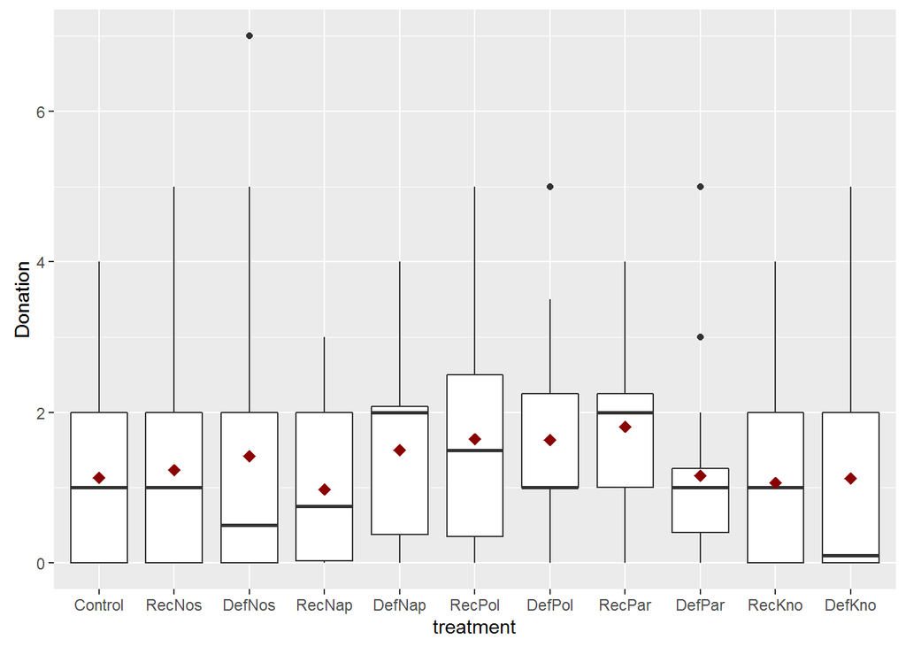

```
##
##  Kruskal-Wallis rank sum test
##
## data:  dfbel$Donation by dfbel$treatment
## Kruskal-Wallis chi-squared = 11.22, df = 10, p-value = 0.3406
```

*The Kruskal Wallis test is not significant. This means that there are also no significant differences in Donations for those that believed we cooperated with Julia Verlinden.*

## Check extensive margin by treatment only for those that believed we cooperated with Julia Verlinden

```
##
##               Control RecNos DefNos RecNap DefNap RecPol DefPol RecPar
##   Not donated      13     11     16      5      6      4      2      1
##   Donated          18     20     18     13     18     11     13     15
##
##               DefPar RecKno DefKno
##   Not donated      3      8     10
##   Donated         13     17     11
```

```
##
##  Pearson's Chi-squared test with simulated p-value (based on 2000
##  replicates)
##
## data:  table(dfbel$Donated, dfbel$treatment)
## X-squared = 16.896, df = NA, p-value = 0.06847
```

```
##
## z test of coefficients:
##
##                                      Estimate Std. Error z value Pr(>|z|)
## (Intercept)                           0.59784    0.38443  1.5551  0.11991
## RecvsDefDef                          -0.48005    0.52115 -0.9211  0.35698
## SourcetypeNameAndPicture              0.35767    0.66198  0.5403  0.58898
## SourcetypeKnowledgeable               0.15593    0.58359  0.2672  0.78931
## SourcetypePolitical                   0.41376    0.71086  0.5821  0.56053
## SourcetypePartisan                    2.11021    1.12538  1.8751  0.06078
## RecvsDefDef:SourcetypeNameAndPicture  0.62315    0.89168  0.6989  0.48464
## RecvsDefDef:SourcetypeKnowledgeable  -0.17841    0.81524 -0.2188  0.82677
## RecvsDefDef:SourcetypePolitical       1.34026    1.11095  1.2064  0.22766
## RecvsDefDef:SourcetypePartisan       -0.76166    1.34928 -0.5645  0.57242
##
## (Intercept)
## RecvsDefDef
## SourcetypeNameAndPicture
## SourcetypeKnowledgeable
## SourcetypePolitical
## SourcetypePartisan                   .
## RecvsDefDef:SourcetypeNameAndPicture
## RecvsDefDef:SourcetypeKnowledgeable
## RecvsDefDef:SourcetypePolitical
## RecvsDefDef:SourcetypePartisan
## ---
## Signif. codes:  0 '***' 0.001 '**' 0.01 '*' 0.05 '.' 0.1 ' ' 1
```

# Treatment interactions with…

## … personal Interest and Knowledge w.r.t climate protection

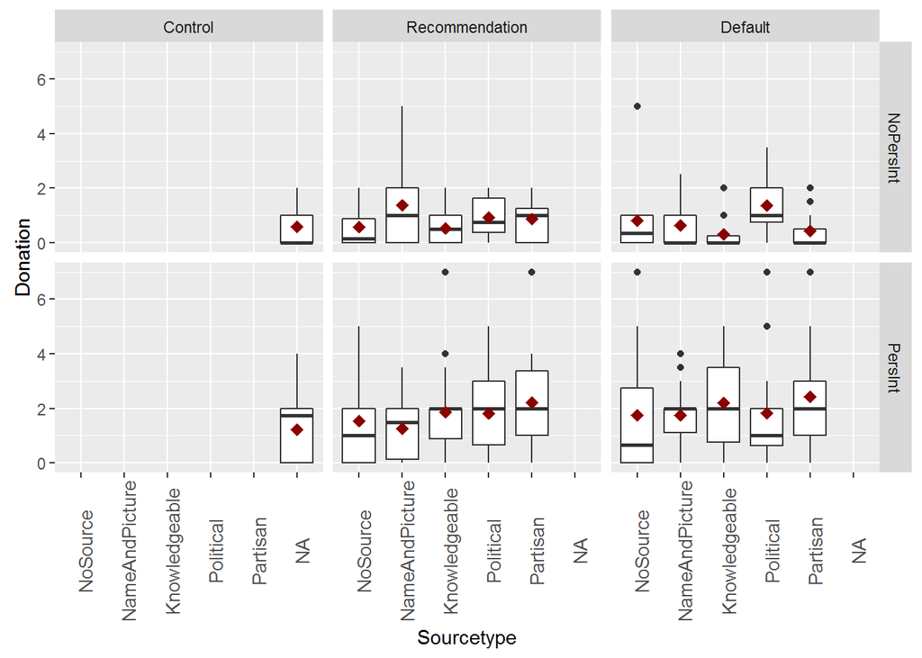

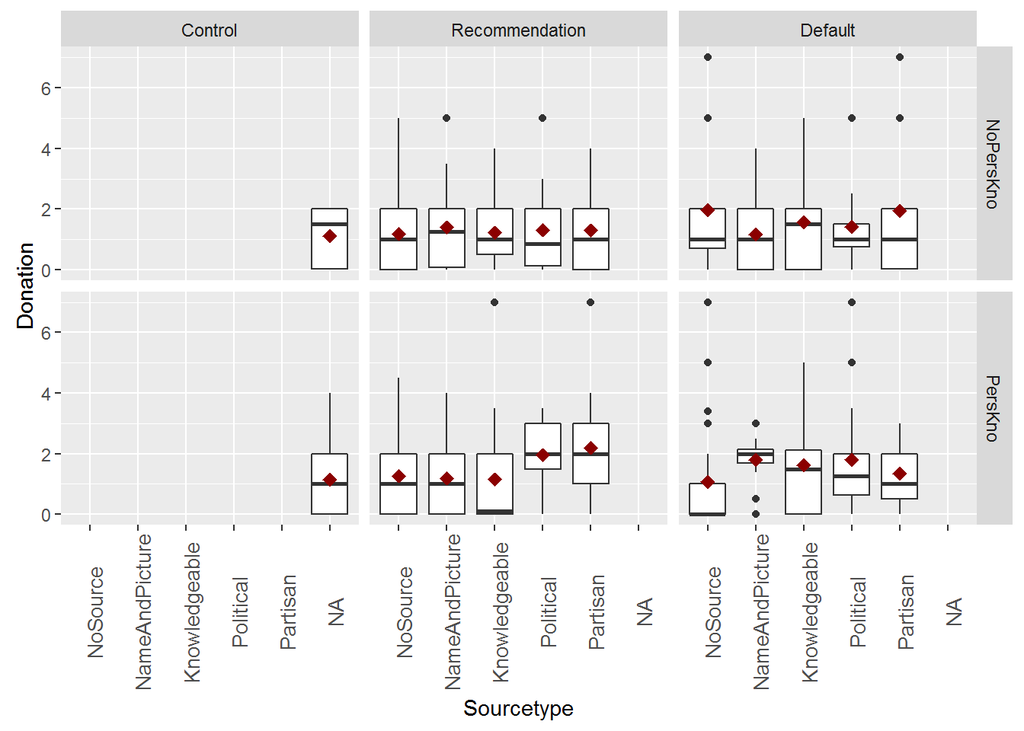

*No obvious and interesting effects appearent.*

## … assessment of source interest and knowledge w.r.t climate protection

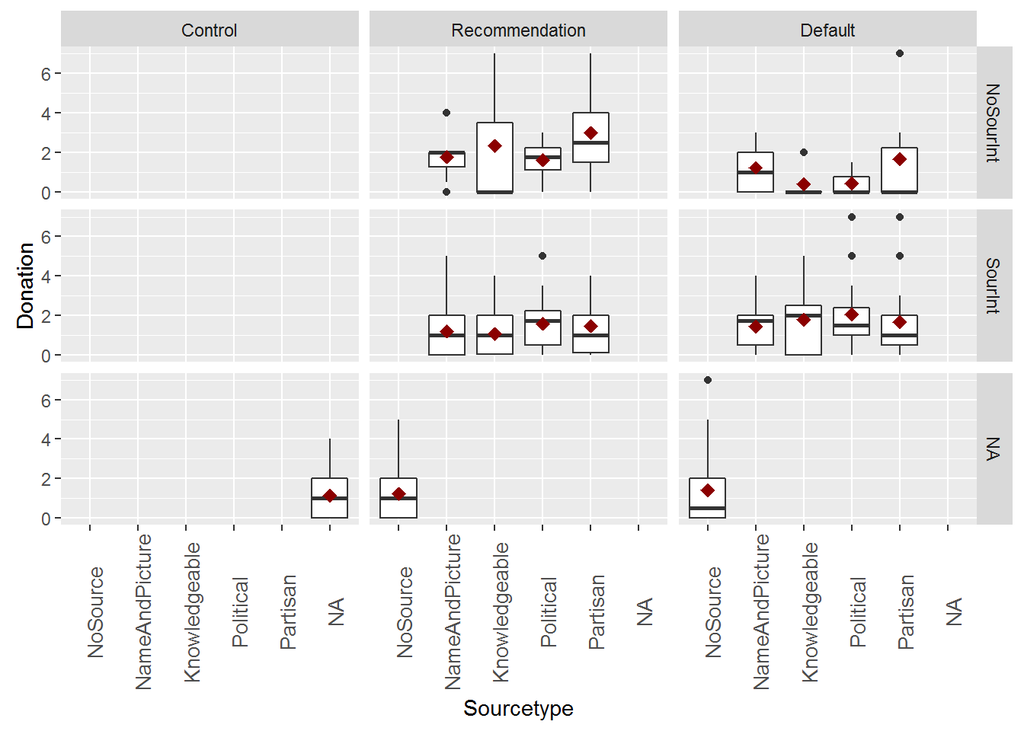

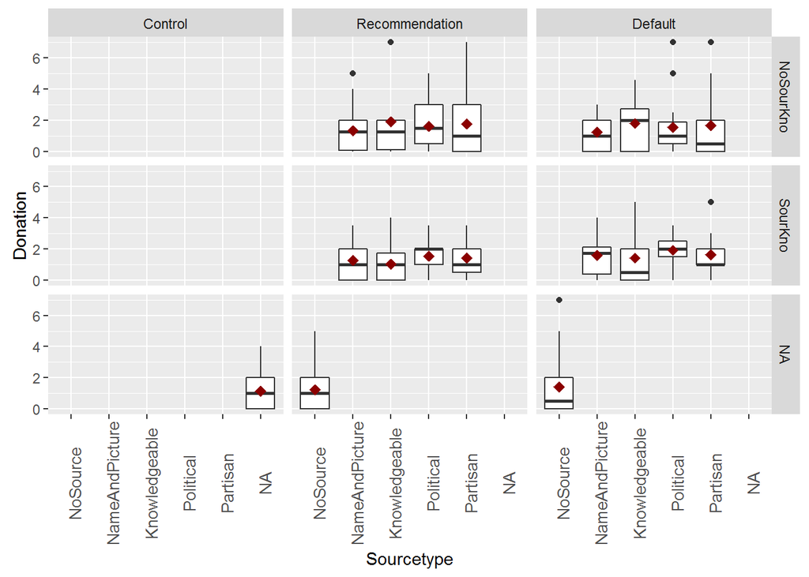

*No obvious and interesting effects appearent.*

## … alignment of interest/ knowledge between subject and the subject’s perception of the source

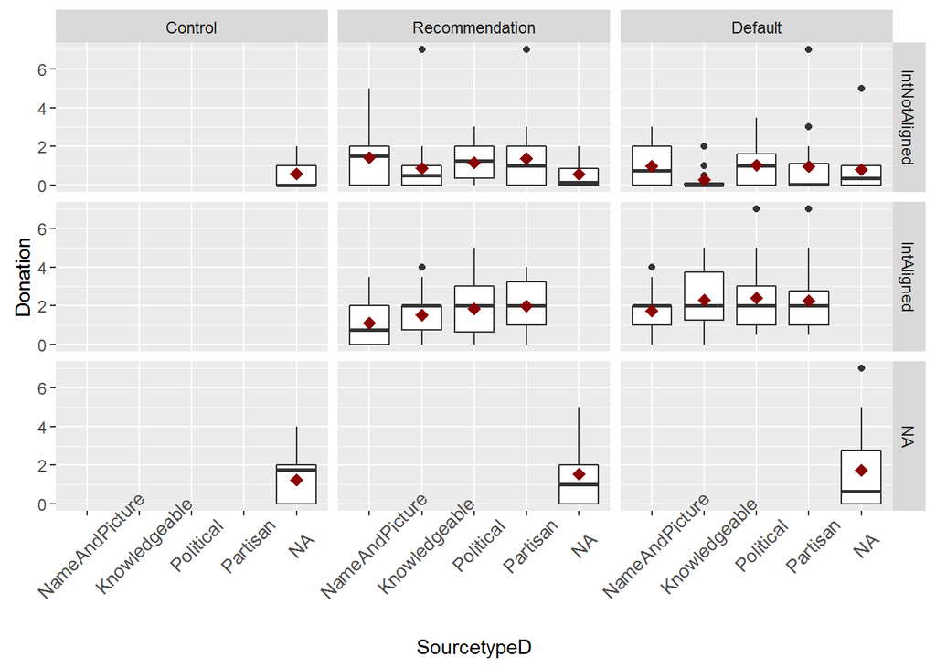

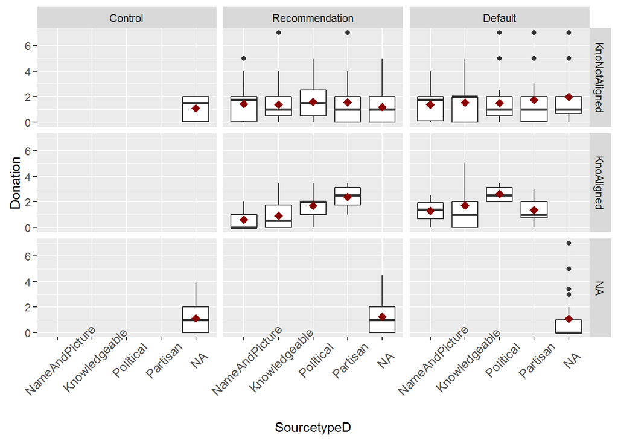

*No obvious and interesting effects appearent.*

## … warm Glow feeling/ feeling of guilt when (not) protecting the climate

```
##
## z test of coefficients:
##
##                  Estimate Std. Error z value Pr(>|z|)
## (Intercept)      0.597837   0.381350  1.5677  0.11695
## treatmentRecNos  0.144100   0.545693  0.2641  0.79173
## treatmentDefNos -0.241162   0.520337 -0.4635  0.64303
## treatmentRecNap -0.903219   0.522941 -1.7272  0.08413 .
## treatmentDefNap  0.095310   0.534944  0.1782  0.85859
## treatmentRecPol -0.087011   0.532013 -0.1636  0.87008
## treatmentDefPol  0.745898   0.601924  1.2392  0.21528
## treatmentRecPar  0.413764   0.566877  0.7299  0.46545
## treatmentDefPar -0.118264   0.523416 -0.2259  0.82124
## treatmentRecKno -0.038221   0.529698 -0.0722  0.94248
## treatmentDefKno  0.277632   0.540035  0.5141  0.60718
## ---
## Signif. codes:  0 '***' 0.001 '**' 0.01 '*' 0.05 '.' 0.1 ' ' 1
```

```
##
##  Pearson's Chi-squared test with simulated p-value (based on 2000
##  replicates)
##
## data:  df$warmGlow and df$treatment
## X-squared = 38.339, df = NA, p-value = 0.5647
```

*Warm Glow experience does not significantly differ by treatment.*

```
##
##  Wilcoxon rank sum test with continuity correction
##
## data:  df$Donation by df$warmGlowD
## W = 9218.5, p-value = 1.092e-08
## alternative hypothesis: true location shift is not equal to 0
```

```
##
##  Pearson's Chi-squared test with Yates' continuity correction
##
## data:  table(df$Donated, df$warmGlowD)
## X-squared = 32.489, df = 1, p-value = 1.199e-08
```

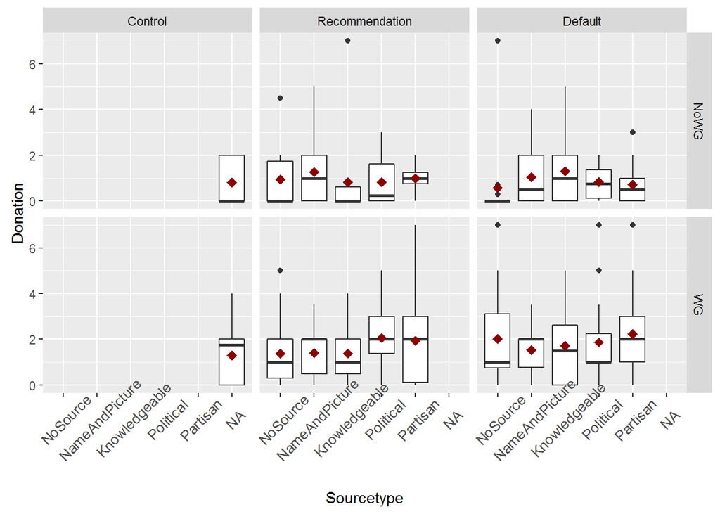

```
##
## t test of coefficients:
##
##                                        Estimate Std. Error t value
## (Intercept)                            0.681035   0.278758  2.4431
## RecvsDefDDef                           0.261040   0.423390  0.6165
## SourcetypeNameAndPicture               0.292947   0.344698  0.8499
## SourcetypeKnowledgeable               -0.017032   0.355166 -0.0480
## SourcetypePolitical                    0.407420   0.323537  1.2593
## SourcetypePartisan                     0.402085   0.382836  1.0503
## warmGlowDWG                            0.818472   0.172686  4.7397
## RecvsDefDDef:SourcetypeNameAndPicture -0.404912   0.525741 -0.7702
## RecvsDefDDef:SourcetypeKnowledgeable   0.091330   0.571609  0.1598
## RecvsDefDDef:SourcetypePolitical      -0.343456   0.559306 -0.6141
## RecvsDefDDef:SourcetypePartisan       -0.184982   0.596564 -0.3101
##                                        Pr(>|t|)
## (Intercept)                             0.01512 *
## RecvsDefDDef                            0.53798
## SourcetypeNameAndPicture                0.39605
## SourcetypeKnowledgeable                 0.96178
## SourcetypePolitical                     0.20888
## SourcetypePartisan                      0.29440
## warmGlowDWG                           3.259e-06 ***
## RecvsDefDDef:SourcetypeNameAndPicture   0.44178
## RecvsDefDDef:SourcetypeKnowledgeable    0.87316
## RecvsDefDDef:SourcetypePolitical        0.53961
## RecvsDefDDef:SourcetypePartisan         0.75671
## ---
## Signif. codes:  0 '***' 0.001 '**' 0.01 '*' 0.05 '.' 0.1 ' ' 1
```

```
##
## z test of coefficients:
##
##                                        Estimate Std. Error z value
## (Intercept)                           -0.368130   0.437827 -0.8408
## RecvsDefDDef                          -0.396613   0.532576 -0.7447
## SourcetypeNameAndPicture               0.677326   0.597075  1.1344
## SourcetypeKnowledgeable                0.336656   0.561456  0.5996
## SourcetypePolitical                    0.847480   0.582683  1.4544
## SourcetypePartisan                     0.365808   0.638296  0.5731
## warmGlowDWG                            1.507818   0.273210  5.5189
## RecvsDefDDef:SourcetypeNameAndPicture  0.169697   0.809486  0.2096
## RecvsDefDDef:SourcetypeKnowledgeable   0.020183   0.775814  0.0260
## RecvsDefDDef:SourcetypePolitical       0.414140   0.860565  0.4812
## RecvsDefDDef:SourcetypePartisan        0.786358   0.836185  0.9404
##                                        Pr(>|z|)
## (Intercept)                              0.4005
## RecvsDefDDef                             0.4564
## SourcetypeNameAndPicture                 0.2566
## SourcetypeKnowledgeable                  0.5488
## SourcetypePolitical                      0.1458
## SourcetypePartisan                       0.5666
## warmGlowDWG                           3.411e-08 ***
## RecvsDefDDef:SourcetypeNameAndPicture    0.8340
## RecvsDefDDef:SourcetypeKnowledgeable     0.9792
## RecvsDefDDef:SourcetypePolitical         0.6303
## RecvsDefDDef:SourcetypePartisan          0.3470
## ---
## Signif. codes:  0 '***' 0.001 '**' 0.01 '*' 0.05 '.' 0.1 ' ' 1
```

- *Based on the Wilcoxon test, average donations differ between groups that feel or do not feel warm glow when contributing to climate change.*
- *Based on the Chi² Test, the amount of people donating differs between groups that feel or do not feel warm glow when contributing to climate change.*
- *Based on the robust OLS regression, warm Glow is highly positively significant as a predictor for average Donations, when controlling for treatments and interactions, which themselves are all insignificant (Which they had been before anyway). When including warm Glow as a part of a tripple interaction term, every predictor becomes insignificant (not reported here).*
- *Based on the robust logistic regression, warm Glow is a highly positively significant predictor for the likelihood to donate anything, when controlling for treatments and interactions, which themselves are all insignificant (which they had been before anyway). When including warm glow as a part of a triple interaction term, every predictor is inisignificant except for warm glow, which is significant at p < .1.*

## … judging carbon offsetting as a efficient way to protect the climate

```
##
##  Pearson's Chi-squared test with simulated p-value (based on 2000
##  replicates)
##
## data:  table(df$retireEffic, df$treatment)
## X-squared = 36.118, df = NA, p-value = 0.6407
```

```
##
## z test of coefficients:
##
##                  Estimate Std. Error z value Pr(>|z|)
## (Intercept)     -0.597837   0.381350 -1.5677   0.1170
## treatmentRecNos  0.403681   0.529015  0.7631   0.4454
## treatmentDefNos -0.423814   0.548986 -0.7720   0.4401
## treatmentRecNap  0.415515   0.521124  0.7973   0.4253
## treatmentDefNap  0.038221   0.529698  0.0722   0.9425
## treatmentRecPol -0.190620   0.543643 -0.3506   0.7259
## treatmentDefPol -0.044017   0.550413 -0.0800   0.9363
## treatmentRecPar -0.249461   0.556101 -0.4486   0.6537
## treatmentDefPar  0.118264   0.523416  0.2259   0.8212
## treatmentRecKno  0.038221   0.529698  0.0722   0.9425
## treatmentDefKno -0.277632   0.540035 -0.5141   0.6072
```

*Judgment (dummy) is independent of treatment*

## Average donation efficiency-judgment differences (by treatment)

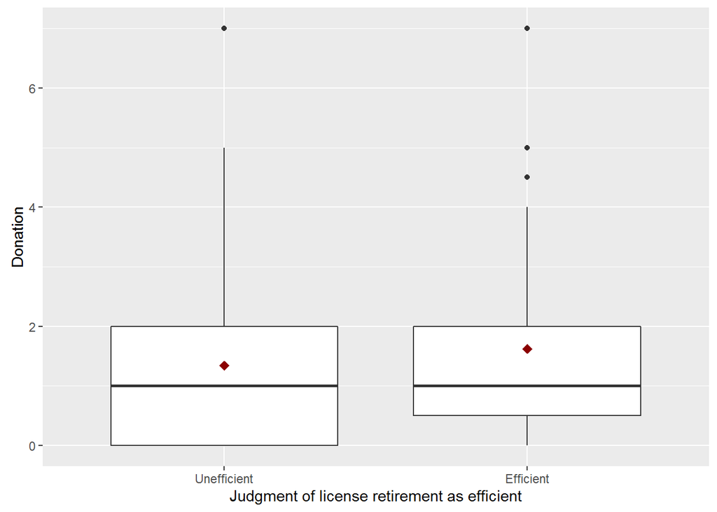

```
##
##  Wilcoxon rank sum test with continuity correction
##
## data:  df$Donation by df$retireEffD
## W = 11934, p-value = 0.008118
## alternative hypothesis: true location shift is not equal to 0
```

*Based on the Wilcoxon test we can confidently reject the null hypothesis of equal median donations (Assuming similar distributions) of those that judge carbon license destruction as an efficient measure to fight climate change vs. does who do not.*

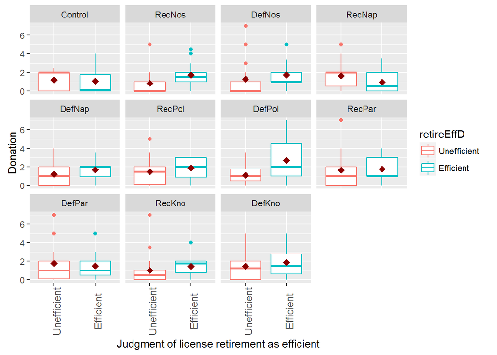

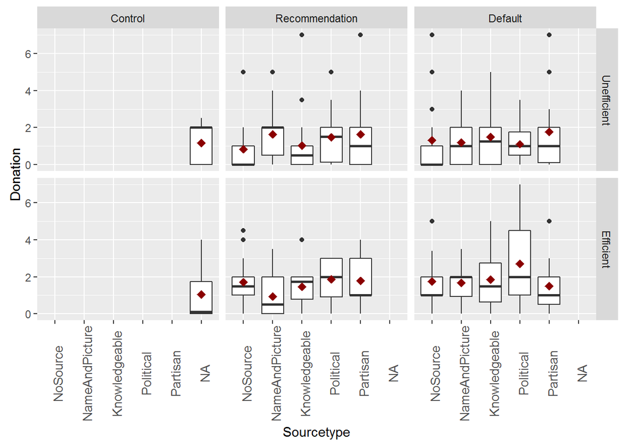

```
##
## t test of coefficients:
##
##                                                            Estimate
## (Intercept)                                               0.8411765
## RecvsDefDef                                               0.4668235
## SourcetypeNameAndPicture                                  0.7977124
## SourcetypeKnowledgeable                                   0.1826331
## SourcetypePolitical                                       0.6360963
## SourcetypePartisan                                        0.8016807
## retireEffDEfficient                                       0.8731092
## RecvsDefDef:SourcetypeNameAndPicture                     -0.9057124
## RecvsDefDef:SourcetypeKnowledgeable                      -0.0072997
## RecvsDefDef:SourcetypePolitical                          -0.8388331
## RecvsDefDef:SourcetypePartisan                           -0.3430140
## RecvsDefDef:retireEffDEfficient                          -0.4366648
## SourcetypeNameAndPicture:retireEffDEfficient             -1.5719981
## SourcetypeKnowledgeable:retireEffDEfficient              -0.4302521
## SourcetypePolitical:retireEffDEfficient                  -0.4803820
## SourcetypePartisan:retireEffDEfficient                   -0.7381886
## RecvsDefDef:SourcetypeNameAndPicture:retireEffDEfficient  1.6188870
## RecvsDefDef:SourcetypeKnowledgeable:retireEffDEfficient   0.3704743
## RecvsDefDef:SourcetypePolitical:retireEffDEfficient       1.6386744
## RecvsDefDef:SourcetypePartisan:retireEffDEfficient        0.0350775
##                                                          Std. Error
## (Intercept)                                               0.3217244
## RecvsDefDef                                               0.5577730
## SourcetypeNameAndPicture                                  0.4619594
## SourcetypeKnowledgeable                                   0.4818675
## SourcetypePolitical                                       0.4332746
## SourcetypePartisan                                        0.5106862
## retireEffDEfficient                                       0.4857782
## RecvsDefDef:SourcetypeNameAndPicture                      0.6986512
## RecvsDefDef:SourcetypeKnowledgeable                       0.7531452
## RecvsDefDef:SourcetypePolitical                           0.6659074
## RecvsDefDef:SourcetypePartisan                            0.8303627
## RecvsDefDef:retireEffDEfficient                           0.8427616
## SourcetypeNameAndPicture:retireEffDEfficient              0.6539388
## SourcetypeKnowledgeable:retireEffDEfficient               0.6867432
## SourcetypePolitical:retireEffDEfficient                   0.6695860
```

[output cut: 34 more lines]

```
## RecvsDefDef:SourcetypeNameAndPicture
## RecvsDefDef:SourcetypeKnowledgeable
## RecvsDefDef:SourcetypePolitical
## RecvsDefDef:SourcetypePartisan
## RecvsDefDef:retireEffDEfficient
## SourcetypeNameAndPicture:retireEffDEfficient             *
## SourcetypeKnowledgeable:retireEffDEfficient
## SourcetypePolitical:retireEffDEfficient
## SourcetypePartisan:retireEffDEfficient
## RecvsDefDef:SourcetypeNameAndPicture:retireEffDEfficient
## RecvsDefDef:SourcetypeKnowledgeable:retireEffDEfficient
## RecvsDefDef:SourcetypePolitical:retireEffDEfficient
## RecvsDefDef:SourcetypePartisan:retireEffDEfficient
## ---
## Signif. codes:  0 '***' 0.001 '**' 0.01 '*' 0.05 '.' 0.1 ' ' 1
```

*Based on the graphical representation of the interaction effects depicted partly in the regression results, it would make sense to change the base-category. For example, in this case there might also be an interaction of efficiency judgment and the effect from knowledgeable source information vs just name and picture (crossover interaction).*

## … moral duty to protect the climate

```
##
##  Pearson's Chi-squared test
##
## data:  table(df$moralD, df$treatment)
## X-squared = 20.174, df = 10, p-value = 0.02765
```

```
##
## z test of coefficients:
##
##                   Estimate Std. Error z value Pr(>|z|)
## (Intercept)      0.5978370  0.3813503  1.5677  0.11695
## treatmentRecNos -0.2724146  0.5311829 -0.5128  0.60806
## treatmentDefNos -0.2411621  0.5203372 -0.4635  0.64303
## treatmentRecNap -0.9032187  0.5229405 -1.7272  0.08413 .
## treatmentDefNap -0.5372124  0.5202330 -1.0326  0.30177
## treatmentRecPol  1.0885620  0.6245533  1.7429  0.08134 .
## treatmentDefPol  0.5472953  0.5829055  0.9389  0.34778
## treatmentRecPar -0.1923719  0.5373743 -0.3580  0.72035
## treatmentDefPar  0.2776317  0.5400351  0.5141  0.60718
## treatmentRecKno -0.6584616  0.5202330 -1.2657  0.20562
## treatmentDefKno  0.0082988  0.5275852  0.0157  0.98745
## ---
## Signif. codes:  0 '***' 0.001 '**' 0.01 '*' 0.05 '.' 0.1 ' ' 1
```

*Moral duty to protect climate is significantly different in treatments (negative predictor of RecNap and positive predictor in RecPol, both only p < .1).*

## Average donation moral duty differences (by treatment)

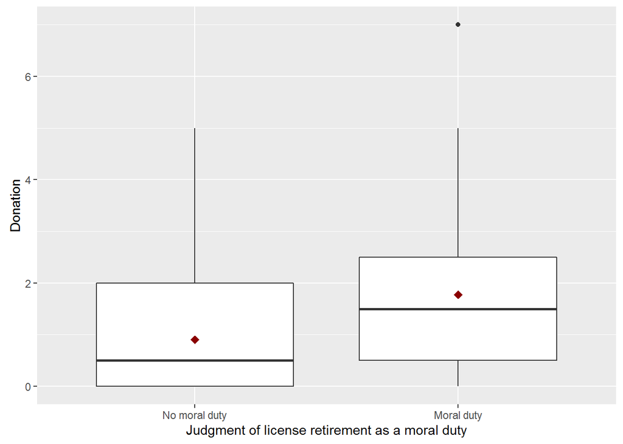

```
##
##  Wilcoxon rank sum test with continuity correction
##
## data:  df$Donation by df$moralD
## W = 10152, p-value = 3.236e-07
## alternative hypothesis: true location shift is not equal to 0
```

*The significant differences shown by the Wilcoxon test are not really dependable, since moral duty correlates with treatments. Therefore, the next regressions account for treatments.*

```
##
## t test of coefficients:
##
##                  Estimate Std. Error t value  Pr(>|t|)
## (Intercept)       0.57297    0.22298  2.5696   0.01061 *
## treatmentRecNos   0.15915    0.31004  0.5133   0.60804
## treatmentDefNos   0.34062    0.40151  0.8483   0.39684
## treatmentRecNap   0.38047    0.32574  1.1680   0.24362
## treatmentDefNap   0.35620    0.27801  1.2813   0.20097
## treatmentRecPol   0.29559    0.29754  0.9934   0.32120
## treatmentDefPol   0.42456    0.37899  1.1202   0.26340
## treatmentRecPar   0.59023    0.35081  1.6825   0.09339 .
## treatmentDefPar   0.47981    0.36377  1.3190   0.18806
## treatmentRecKno   0.19156    0.32133  0.5962   0.55147
## treatmentDefKno   0.46021    0.34247  1.3438   0.17990
## moralDMoral duty  0.86689    0.15146  5.7236 2.282e-08 ***
## ---
## Signif. codes:  0 '***' 0.001 '**' 0.01 '*' 0.05 '.' 0.1 ' ' 1
```

```
##
## t test of coefficients:
##
##                                                         Estimate
## (Intercept)                                             0.600000
## RecvsDefDDef                                            0.092857
## SourcetypeNameAndPicture                                0.931579
## SourcetypeKnowledgeable                                 0.105882
## SourcetypePolitical                                    -0.100000
## SourcetypePartisan                                      0.400000
## moralDMoral duty                                        1.094444
## RecvsDefDDef:SourcetypeNameAndPicture                  -0.624436
## RecvsDefDDef:SourcetypeKnowledgeable                   -0.040406
## RecvsDefDDef:SourcetypePolitical                        1.050000
## RecvsDefDDef:SourcetypePartisan                        -0.682857
## RecvsDefDDef:moralDMoral duty                           0.147698
## SourcetypeNameAndPicture:moralDMoral duty              -1.590309
## SourcetypeKnowledgeable:moralDMoral duty               -0.106577
## SourcetypePolitical:moralDMoral duty                    0.209259
## SourcetypePartisan:moralDMoral duty                     0.044444
## RecvsDefDDef:SourcetypeNameAndPicture:moralDMoral duty  1.077578
## RecvsDefDDef:SourcetypeKnowledgeable:moralDMoral duty   0.156101
## RecvsDefDDef:SourcetypePolitical:moralDMoral duty      -1.435168
## RecvsDefDDef:SourcetypePartisan:moralDMoral duty        0.490913
##                                                        Std. Error t value
## (Intercept)                                              0.233720  2.5672
## RecvsDefDDef                                             0.435133  0.2134
## SourcetypeNameAndPicture                                 0.404610  2.3024
## SourcetypeKnowledgeable                                  0.299625  0.3534
## SourcetypePolitical                                      0.427254 -0.2341
## SourcetypePartisan                                       0.383615  1.0427
## moralDMoral duty                                         0.433710  2.5234
## RecvsDefDDef:SourcetypeNameAndPicture                    0.595516 -1.0486
## RecvsDefDDef:SourcetypeKnowledgeable                     0.547108 -0.0739
## RecvsDefDDef:SourcetypePolitical                         0.666847  1.5746
## RecvsDefDDef:SourcetypePartisan                          0.568061 -1.2021
## RecvsDefDDef:moralDMoral duty                            0.777616  0.1899
## SourcetypeNameAndPicture:moralDMoral duty                0.618670 -2.5705
## SourcetypeKnowledgeable:moralDMoral duty                 0.661937 -0.1610
## SourcetypePolitical:moralDMoral duty                     0.613349  0.3412
```

[output cut: 13 more lines]

```
## RecvsDefDDef:SourcetypeNameAndPicture                   0.29522
## RecvsDefDDef:SourcetypeKnowledgeable                    0.94118
## RecvsDefDDef:SourcetypePolitical                        0.11640
## RecvsDefDDef:SourcetypePartisan                         0.23027
## RecvsDefDDef:moralDMoral duty                           0.84949
## SourcetypeNameAndPicture:moralDMoral duty               0.01063 *
## SourcetypeKnowledgeable:moralDMoral duty                0.87219
## SourcetypePolitical:moralDMoral duty                    0.73321
## SourcetypePartisan:moralDMoral duty                     0.94824
## RecvsDefDDef:SourcetypeNameAndPicture:moralDMoral duty  0.26726
## RecvsDefDDef:SourcetypeKnowledgeable:moralDMoral duty   0.88120
## RecvsDefDDef:SourcetypePolitical:moralDMoral duty       0.16858
## RecvsDefDDef:SourcetypePartisan:moralDMoral duty        0.63936
## ---
## Signif. codes:  0 '***' 0.001 '**' 0.01 '*' 0.05 '.' 0.1 ' ' 1
```

- *When controlling for treatments, moral duty is a significant positive predictor for the Donation amount.*
- *When implementing moral duty in a triple interaction, there is a positive main effect for both the provision of a name and picture as opposed to no source information and of moral duty as opposed to no moral duty. The interaction of moral duty and providing name and picture of the source is negative, meaning that the effect of providing name and picture is negative when subjects are morally responsible and positive when subjects are not morally responsible.*

**Mind that here is suddenly became pretty obvious how to interpret the interaction effects. I have to keep in mind that the covariates do not establish causal effects on the dependent variable, however, the respective treatment variables do. Therefore, I should alsways phrase the interaction interpretations like I did above: The covariates interact with the causal effects of the treatment on the dependent variable.**

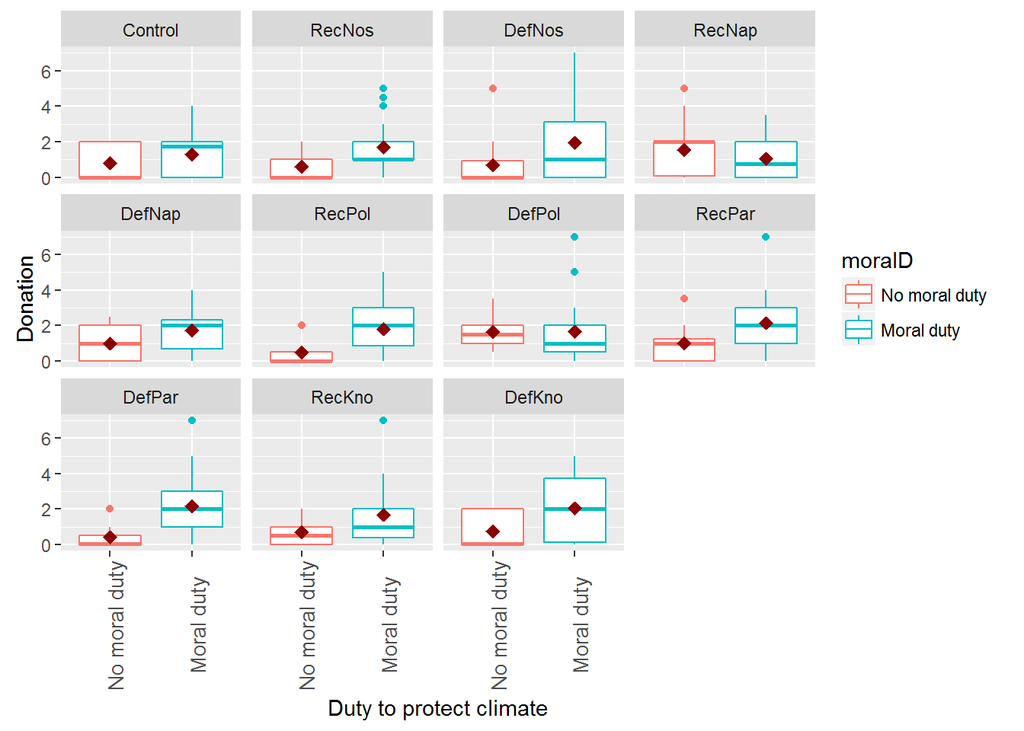

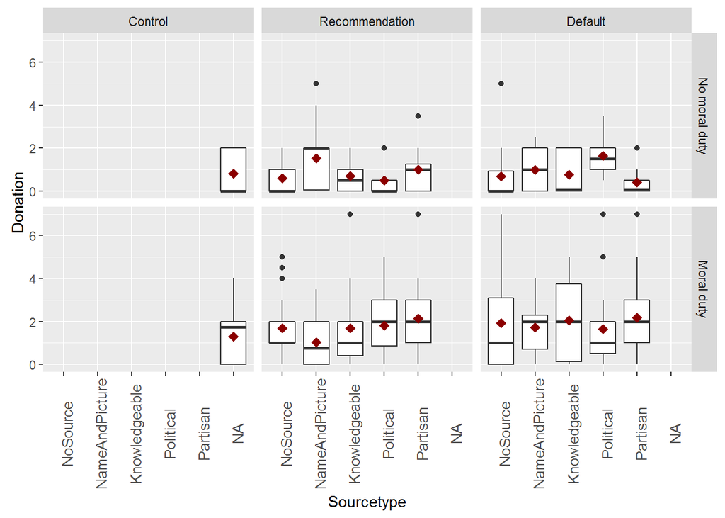

*The latter graphic shows the negative interaction effect. The Figure indicates that there might also be an interaction of moral duty and chancing from Name and picture to knowledgeable source information. Or from knowledgeable to political, or political to partisan for defaults.*

**I will have to decide (theoretically) which of these interactions is interesting enough to discuss. However, I always have to keep in mind that the model may have few observations in the respective categories and might therefore not be very robust.**

## … income

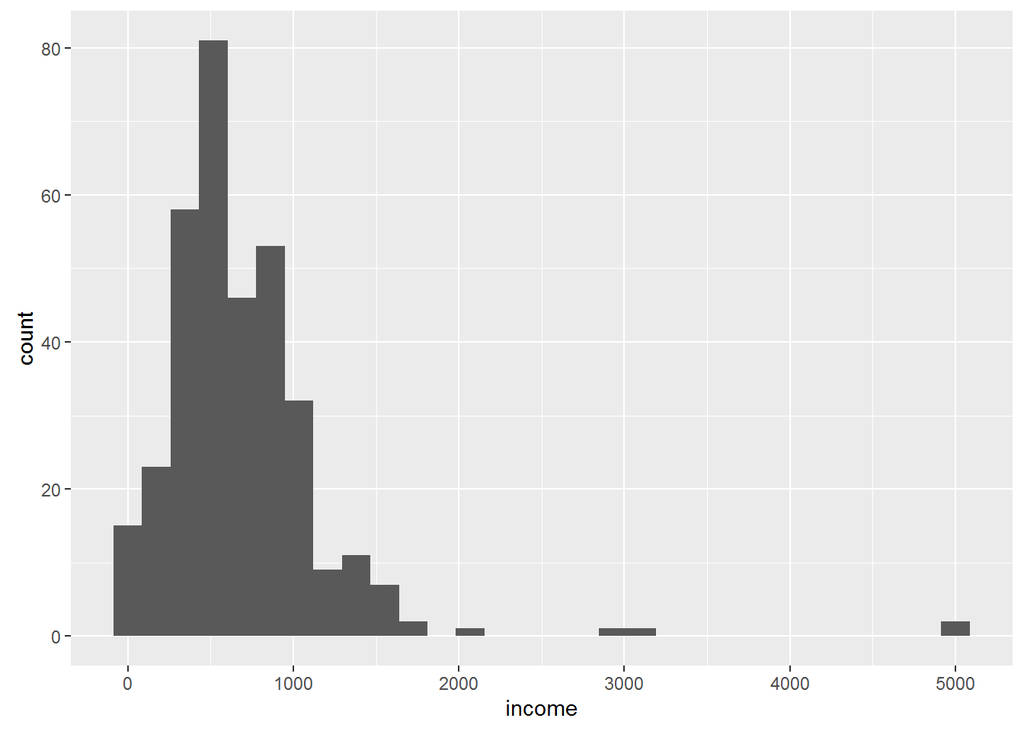

```
##
## Call:
## lm(formula = income ~ treatment, data = df)
##
## Residuals:
##    Min     1Q Median     3Q    Max
## -843.1 -284.3  -55.8  169.0 4260.3
##
## Coefficients:
##                 Estimate Std. Error t value Pr(>|t|)
## (Intercept)       739.68      93.38   7.921  3.6e-14 ***
## treatmentRecNos   -83.87     132.06  -0.635    0.526
## treatmentDefNos  -121.15     129.11  -0.938    0.349
## treatmentRecNap   -87.42     132.06  -0.662    0.508
## treatmentDefNap   -55.08     131.02  -0.420    0.674
## treatmentRecPol   -36.45     132.06  -0.276    0.783
## treatmentDefPol   103.43     134.31   0.770    0.442
## treatmentRecPar  -120.03     135.55  -0.886    0.376
## treatmentDefPar   -26.34     130.04  -0.203    0.840
## treatmentRecKno  -117.10     132.06  -0.887    0.376
## treatmentDefKno    -8.71     132.06  -0.066    0.947
## ---
## Signif. codes:  0 '***' 0.001 '**' 0.01 '*' 0.05 '.' 0.1 ' ' 1
##
## Residual standard error: 519.9 on 331 degrees of freedom
##   (12 observations deleted due to missingness)
## Multiple R-squared:  0.01503,    Adjusted R-squared:  -0.01472
## F-statistic: 0.5052 on 10 and 331 DF,  p-value: 0.8862
```

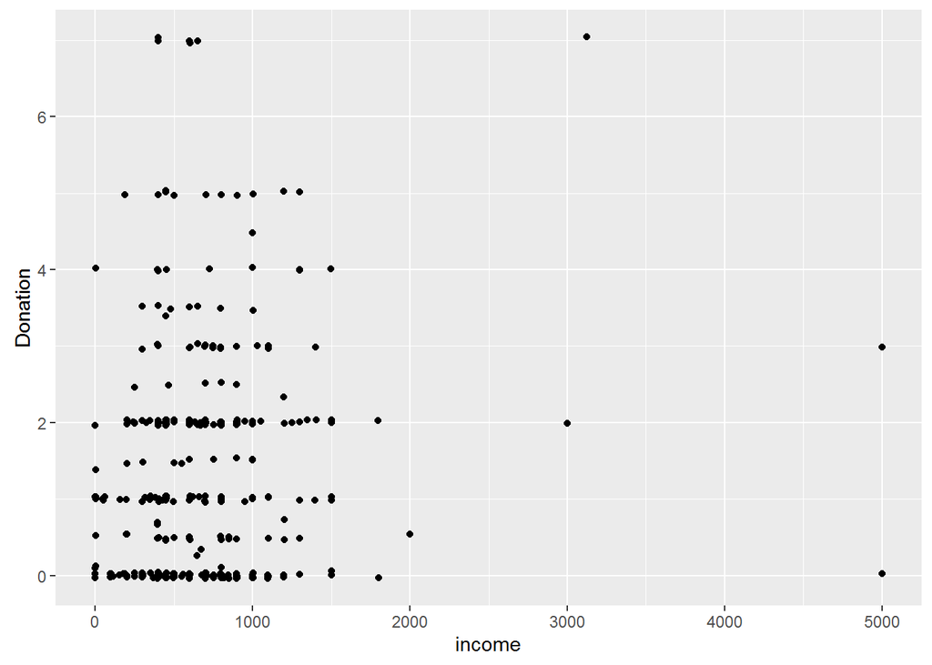

```
##
## t test of coefficients:
##
##                    Estimate  Std. Error t value  Pr(>|t|)
## (Intercept)      0.93226870  0.22935506  4.0647 6.016e-05 ***
## treatmentRecNos  0.12590232  0.32832378  0.3835    0.7016
## treatmentDefNos  0.32402659  0.41351884  0.7836    0.4338
## treatmentRecNap  0.18492622  0.31686793  0.5836    0.5599
## treatmentDefNap  0.23888511  0.28841612  0.8283    0.4081
## treatmentRecPol  0.49695233  0.31496742  1.5778    0.1156
## treatmentDefPol  0.49495067  0.36068740  1.3722    0.1709
## treatmentRecPar  0.59662470  0.38540864  1.5480    0.1226
## treatmentDefPar  0.57486469  0.39359535  1.4605    0.1451
## treatmentRecKno -0.09737236  0.28066683 -0.3469    0.7289
## treatmentDefKno  0.24429035  0.34896740  0.7000    0.4844
## income           0.00027037  0.00019373  1.3956    0.1638
## ---
## Signif. codes:  0 '***' 0.001 '**' 0.01 '*' 0.05 '.' 0.1 ' ' 1
```

```
##
## z test of coefficients:
##
##                    Estimate  Std. Error z value Pr(>|z|)
## (Intercept)      3.1569e-01  4.0315e-01  0.7831  0.43359
## treatmentRecNos  2.7351e-01  5.3293e-01  0.5132  0.60779
## treatmentDefNos -2.0605e-01  5.0965e-01 -0.4043  0.68599
## treatmentRecNap  4.1766e-01  5.3982e-01  0.7737  0.43910
## treatmentDefNap  6.1357e-01  5.4548e-01  1.1248  0.26067
## treatmentRecPol  9.0719e-01  5.7314e-01  1.5829  0.11345
## treatmentDefPol  1.2419e+00  6.2545e-01  1.9856  0.04708 *
## treatmentRecPar  5.9245e-01  5.6517e-01  1.0483  0.29451
## treatmentDefPar  8.1436e-01  5.5498e-01  1.4674  0.14228
## treatmentRecKno  4.1805e-01  5.3811e-01  0.7769  0.43723
## treatmentDefKno  1.3422e-01  5.2765e-01  0.2544  0.79921
## income           1.3165e-05  2.3096e-04  0.0570  0.95454
## ---
## Signif. codes:  0 '***' 0.001 '**' 0.01 '*' 0.05 '.' 0.1 ' ' 1
```

*Reported income is neither a significant predictor for the average donation amount, nor for the probability to donate anything.*

## Fractions of participants donating: Pol vs Knowledge

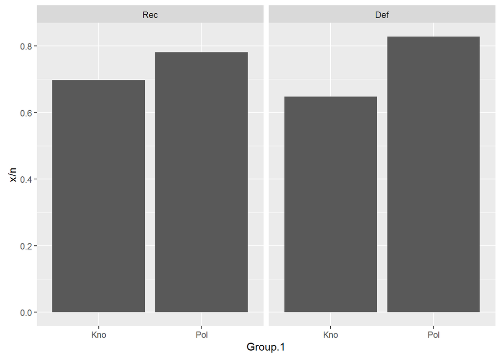

```
##
## z test of coefficients:
##
##                          Estimate Std. Error z value Pr(>|z|)
## (Intercept)               0.83291    0.38485  2.1643  0.03044 *
## RecvsDefDDef             -0.22677    0.53014 -0.4278  0.66883
## KnovsPolPol               0.44006    0.58040  0.7582  0.44833
## RecvsDefDDef:KnovsPolPol  0.52242    0.84810  0.6160  0.53790
## ---
## Signif. codes:  0 '***' 0.001 '**' 0.01 '*' 0.05 '.' 0.1 ' ' 1
```

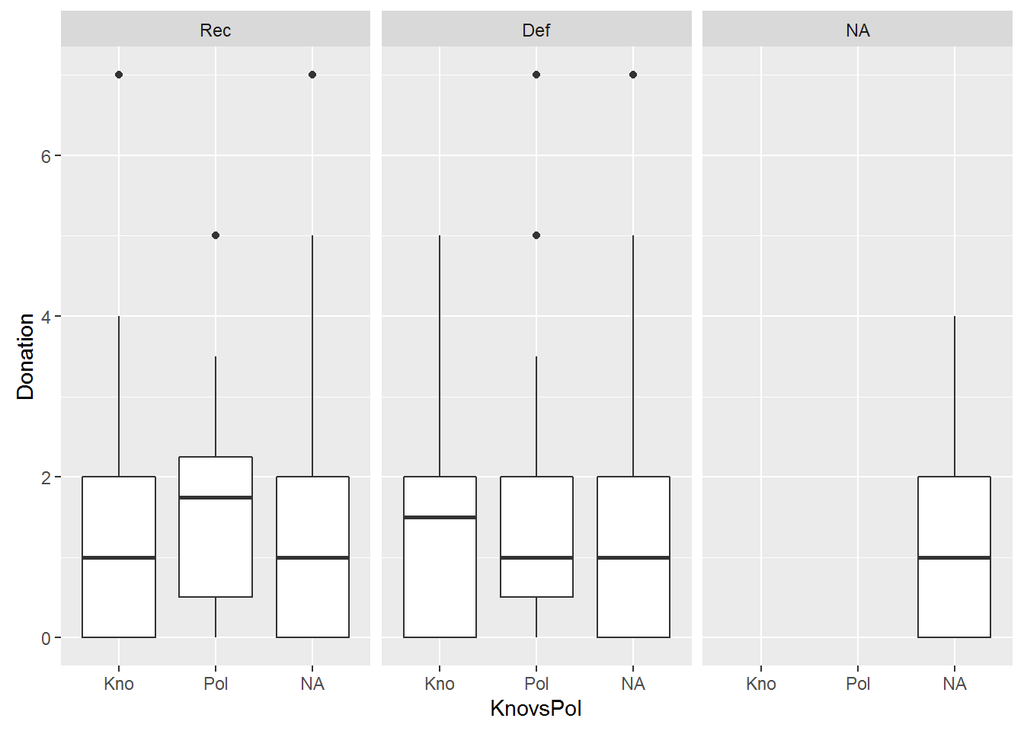

*There is no interaction effect of Knowledge vs political source information and intervention type on the probability to donate anything. There is also no interaction on the average donation amount (regression not reported here).*

# Disaggregated reactance scores (4 categories)

```
##
## Call:
## lm(formula = Donation ~ treatment + as.factor(EmotionResp) +
##     as.factor(ReactCompl) + as.factor(ResistInfl) + as.factor(ReactAdv),
##     data = df)
##
## Residuals:
##     Min      1Q  Median      3Q     Max
## -2.5051 -1.1476 -0.3594  0.7243  5.3430
##
## Coefficients:
##                          Estimate Std. Error t value Pr(>|t|)
## (Intercept)              0.736099   0.453194   1.624   0.1053
## treatmentRecNos         -0.005423   0.399003  -0.014   0.9892
## treatmentDefNos          0.395710   0.402113   0.984   0.3258
## treatmentRecNap          0.235680   0.391344   0.602   0.5474
## treatmentDefNap          0.319443   0.397975   0.803   0.4227
## treatmentRecPol          0.533913   0.397358   1.344   0.1800
## treatmentDefPol          0.683147   0.407705   1.676   0.0948 .
## treatmentRecPar          0.581785   0.404362   1.439   0.1512
## treatmentDefPar          0.657105   0.392813   1.673   0.0953 .
## treatmentRecKno          0.133091   0.391121   0.340   0.7339
## treatmentDefKno          0.547243   0.399653   1.369   0.1718
## as.factor(EmotionResp)1  0.632542   0.397026   1.593   0.1121
## as.factor(EmotionResp)2  0.907914   0.406789   2.232   0.0263 *
## as.factor(EmotionResp)3  0.377753   0.512237   0.737   0.4614
## as.factor(ReactCompl)1   0.211673   0.204646   1.034   0.3017
## as.factor(ReactCompl)2   0.008047   0.250036   0.032   0.9743
## as.factor(ReactCompl)3   0.032521   0.381965   0.085   0.9322
## as.factor(ResistInfl)1  -0.352749   0.436930  -0.807   0.4201
## as.factor(ResistInfl)2  -0.449347   0.457319  -0.983   0.3265
## as.factor(ResistInfl)3  -0.781631   0.590293  -1.324   0.1864
## as.factor(ReactAdv)1    -0.265075   0.208132  -1.274   0.2037
## as.factor(ReactAdv)2     0.826840   0.527648   1.567   0.1181
## ---
## Signif. codes:  0 '***' 0.001 '**' 0.01 '*' 0.05 '.' 0.1 ' ' 1
##
## Residual standard error: 1.548 on 332 degrees of freedom
## Multiple R-squared:  0.05534,    Adjusted R-squared:  -0.004409
## F-statistic: 0.9262 on 21 and 332 DF,  p-value: 0.5571
```

*No significant effects of interest. Partly counter-intuitive. When looking at this with the respective above median dummies for the four reactance categories, there are very often not enough observations in the respective groups (not reported here).*

# Exclude observations with demandEffectD == 1

```
##
##     Control RecNos DefNos RecNap DefNap RecPol DefPol RecPar DefPar RecKno
##   0       5      2      8      4      8      4      7      6      8      5
##   1       5      4      9     13      6      8      7     11      6      8
##   2      16     16     10      9     16     15      9     10     11     10
##   3       4      8      4      3      2      2      4      2      4      7
##   4       1      1      3      4      1      3      2      1      5      3
##
##     DefKno
##   0      7
##   1      6
##   2      9
##   3     10
##   4      2
```

```
##
##  Pearson's Chi-squared test with simulated p-value (based on 2000
##  replicates)
##
## data:  table(df$demandEffect, df$treatment)
## X-squared = 46.611, df = NA, p-value = 0.2154
```

```
##
##  Kruskal-Wallis rank sum test
##
## data:  df$Donation by df$demandEffect
## Kruskal-Wallis chi-squared = 11.166, df = 4, p-value = 0.02476
```

```
##
##                0  1  2  3  4
##   Not donated 28 19 38 16  8
##   Donated     36 64 93 34 18
```

```
##
##  Pearson's Chi-squared test
##
## data:  table(df$Donated, df$demandEffect)
## X-squared = 7.7038, df = 4, p-value = 0.1031
```

```
##
## Call:
## glm(formula = Donated ~ treatment + demandEffectD, family = "binomial",
##     data = df)
##
## Deviance Residuals:
##     Min       1Q   Median       3Q      Max
## -1.8763  -1.3193   0.7313   0.8531   1.1324
##
## Coefficients:
##                     Estimate Std. Error z value Pr(>|z|)
## (Intercept)          0.32765    0.36696   0.893   0.3719
## treatmentRecNos      0.27420    0.52421   0.523   0.6009
## treatmentDefNos     -0.20703    0.50070  -0.413   0.6793
## treatmentRecNap      0.50819    0.52553   0.967   0.3335
## treatmentDefNap      0.65444    0.53448   1.224   0.2208
## treatmentRecPol      0.94748    0.56155   1.687   0.0916 .
## treatmentDefPol      1.24383    0.61183   2.033   0.0421 *
## treatmentRecPar      0.68534    0.55068   1.245   0.2133
## treatmentDefPar      0.85467    0.54484   1.569   0.1167
## treatmentRecKno      0.50945    0.52693   0.967   0.3336
## treatmentDefKno      0.28336    0.51416   0.551   0.5816
## demandEffectDDemEff -0.01378    0.28906  -0.048   0.9620
## ---
## Signif. codes:  0 '***' 0.001 '**' 0.01 '*' 0.05 '.' 0.1 ' ' 1
##
## (Dispersion parameter for binomial family taken to be 1)
##
##     Null deviance: 437.13  on 353  degrees of freedom
## Residual deviance: 425.47  on 342  degrees of freedom
## AIC: 449.47
##
## Number of Fisher Scoring iterations: 4
```

```
##
## Call:
## lm(formula = Donation ~ treatment + demandEffectD, data = df)
##
## Residuals:
##     Min      1Q  Median      3Q     Max
## -1.8643 -1.1637 -0.3692  0.7347  5.8951
##
## Coefficients:
##                     Estimate Std. Error t value Pr(>|t|)
## (Intercept)          1.08973    0.28083   3.880 0.000125 ***
## treatmentRecNos      0.06920    0.39529   0.175 0.861125
## treatmentDefNos      0.27951    0.38571   0.725 0.469148
## treatmentRecNap      0.17555    0.38852   0.452 0.651664
## treatmentDefNap      0.26206    0.38865   0.674 0.500587
## treatmentRecPol      0.46907    0.39131   1.199 0.231464
## treatmentDefPol      0.51089    0.40125   1.273 0.203797
## treatmentRecPar      0.56724    0.39787   1.426 0.154874
## treatmentDefPar      0.50518    0.38618   1.308 0.191706
## treatmentRecKno      0.01522    0.38946   0.039 0.968854
## treatmentDefKno      0.41133    0.38760   1.061 0.289337
## demandEffectDDemEff  0.26367    0.20493   1.287 0.199091
## ---
## Signif. codes:  0 '***' 0.001 '**' 0.01 '*' 0.05 '.' 0.1 ' ' 1
##
## Residual standard error: 1.553 on 342 degrees of freedom
## Multiple R-squared:  0.02072,    Adjusted R-squared:  -0.01078
## F-statistic: 0.6578 on 11 and 342 DF,  p-value: 0.7782
```

```
## group: Control
##   vars  n mean   sd median trimmed  mad min max range skew kurtosis   se
## 1    1 26 1.17 1.16   1.25    1.07 1.48   0   4     4 0.41    -0.84 0.23
## --------------------------------------------------------
## group: RecNos
##   vars  n mean   sd median trimmed  mad min max range skew kurtosis   se
## 1    1 22  1.1 1.36   0.75    0.88 1.11   0 4.5   4.5 1.09     0.11 0.29
## --------------------------------------------------------
## group: DefNos
##   vars  n mean   sd median trimmed  mad min max range skew kurtosis   se
## 1    1 27  1.5 2.16    0.7    1.15 1.04   0   7     7 1.42     0.75 0.42
## --------------------------------------------------------
## group: RecNap
##   vars  n mean   sd median trimmed  mad min max range skew kurtosis   se
## 1    1 26 1.14 1.33   0.75    0.94 1.11   0   5     5 1.15     0.86 0.26
## --------------------------------------------------------
## group: DefNap
##   vars  n mean   sd median trimmed  mad min max range skew kurtosis  se
## 1    1 30 1.43 1.11   1.75    1.35 1.11   0   4     4 0.26    -0.75 0.2
## --------------------------------------------------------
## group: RecPol
##   vars  n mean   sd median trimmed  mad min max range skew kurtosis   se
## 1    1 27 1.54 1.17    1.5    1.53 1.48   0 3.5   3.5 0.03    -1.44 0.23
## --------------------------------------------------------
## group: DefPol
##   vars  n mean  sd median trimmed  mad min max range skew kurtosis   se
## 1    1 23 1.65 1.7      1    1.37 1.48   0   7     7 1.55     2.16 0.35
## --------------------------------------------------------
## group: RecPar
##   vars  n mean   sd median trimmed  mad min max range skew kurtosis   se
## 1    1 27 1.65 1.74      1    1.46 1.48   0   7     7 1.13     0.98 0.33
## --------------------------------------------------------
## group: DefPar
##   vars  n mean   sd median trimmed  mad min max range skew kurtosis   se
## 1    1 25 1.54 1.67      1    1.27 1.48   0   7     7 1.64     2.57 0.33
## --------------------------------------------------------
## group: RecKno
##   vars  n mean   sd median trimmed  mad min max range skew kurtosis   se
## 1    1 23 1.31 1.55      1    1.03 1.48   0   7     7 2.14      5.3 0.32
## --------------------------------------------------------
## group: DefKno
##   vars  n mean   sd median trimmed  mad min max range skew kurtosis  se
## 1    1 22 1.16 1.43    0.5    0.92 0.74   0   5     5 1.07     0.32 0.3
```

```
##
##  Kruskal-Wallis rank sum test
##
## data:  dfnoDE$Donation and dfnoDE$treatment
## Kruskal-Wallis chi-squared = 7.3133, df = 10, p-value = 0.6956
```

```
##
## Call:
## lm(formula = Donation ~ treatment, data = dfnoDE)
##
## Residuals:
##     Min      1Q  Median      3Q     Max
## -1.6522 -1.1522 -0.4963  0.8269  5.6913
##
## Coefficients:
##                  Estimate Std. Error t value Pr(>|t|)
## (Intercept)      1.173077   0.297298   3.946 0.000102 ***
## treatmentRecNos -0.068531   0.439139  -0.156 0.876105
## treatmentDefNos  0.323219   0.416532   0.776 0.438449
## treatmentRecNap -0.034615   0.420443  -0.082 0.934445
## treatmentDefNap  0.256923   0.406187   0.633 0.527585
## treatmentRecPol  0.371368   0.416532   0.892 0.373426
## treatmentDefPol  0.479097   0.433937   1.104 0.270556
## treatmentRecPar  0.475071   0.416532   1.141 0.255084
## treatmentDefPar  0.370923   0.424627   0.874 0.383161
## treatmentRecKno  0.135619   0.433937   0.313 0.754881
## treatmentDefKno -0.009441   0.439139  -0.021 0.982865
## ---
## Signif. codes:  0 '***' 0.001 '**' 0.01 '*' 0.05 '.' 0.1 ' ' 1
##
## Residual standard error: 1.516 on 267 degrees of freedom
## Multiple R-squared:  0.01747,    Adjusted R-squared:  -0.01933
## F-statistic: 0.4748 on 10 and 267 DF,  p-value: 0.9056
```

```
##
## Call:
## glm(formula = Donated ~ treatment, family = "binomial", data = dfnoDE)
##
## Deviance Residuals:
##     Min       1Q   Median       3Q      Max
## -1.9145  -1.3116   0.7002   0.9854   1.0842
##
## Coefficients:
##                 Estimate Std. Error z value Pr(>|z|)
## (Intercept)      0.31015    0.39696   0.781   0.4346
## treatmentRecNos  0.05757    0.58789   0.098   0.9220
## treatmentDefNos -0.08701    0.55460  -0.157   0.8753
## treatmentRecNap  0.15985    0.56575   0.283   0.7775
## treatmentDefNap  0.87943    0.58644   1.500   0.1337
## treatmentRecPol  0.94261    0.60980   1.546   0.1222
## treatmentDefPol  1.24799    0.67839   1.840   0.0658 .
## treatmentRecPar  0.55484    0.57897   0.958   0.3379
## treatmentDefPar  1.34807    0.67468   1.998   0.0457 *
## treatmentRecKno  0.97078    0.64275   1.510   0.1310
## treatmentDefKno  0.05757    0.58789   0.098   0.9220
## ---
## Signif. codes:  0 '***' 0.001 '**' 0.01 '*' 0.05 '.' 0.1 ' ' 1
##
## (Dispersion parameter for binomial family taken to be 1)
##
##     Null deviance: 342.31  on 277  degrees of freedom
## Residual deviance: 328.04  on 267  degrees of freedom
## AIC: 350.04
##
## Number of Fisher Scoring iterations: 4
```

- *ChiÂ²Test suggests that experience of demand Effect does not depend on the treatment.*
- *Kruskal Wallis Test suggests that experiencing a demand effect has an impact on Donation amount.*
- *It is not significant (ChiÂ²) with dependent variable Donated (extensive margin).*
- *In a logistic regression that incorporates treatment as IV and demandEffect as dummy, there is no demand effect.*
- *In the OLS regression, there is also no effect, when controlling for treatment effects.*
- *When only looking at subjects that did not experience a demand effect (judging on the dummy variable), according to the Kruskal Wallis Test, there are also no significant differences across treatments.*
- *According to a logistic regression, the likelihood to donate is higher for those without a demand effect-experience that encountered DefPol and DefPar, with Control as base-category.*

# Double Hurdle Model

*My justification of a double-hurdle model (an extension of the Tobit Model) is that some subjects simply do not contribute to climate protection, they are zero-types. Contrary to Tobit (and p Tobit) models, a double Hurdle Model allows to specify the zero types via a set of subject characteristics, i.e. via independent variables. This is a generalization of the p tobit model, since it allows to vary the p parameter according to subject characteristics. I have to theoretically argue which characteristics are relevant (predict) whether a subject is a zero type and whether the treatment is important for this. Afterwards, the model predicts the amount subjects contribute.* > Source: Engel 2014

```
##
## Call:
## mhurdle(formula = Donation ~ moralD + retireEffD + NosvsSomeD +
##     RecvsDefD | NosvsSomeD + RecvsDefD + belief + gender | 0,
##     data = dfsub)
##
## Frequency of 0:  0.29688
##
## Coefficients :
##                           Estimate Std. Error t-value  Pr(>|t|)
## h1.(Intercept)           -0.215673   0.206372 -1.0451 0.2959906
## h1.moralDMoral duty       0.513003   0.155403  3.3011 0.0009630 ***
## h1.retireEffDEfficient    0.581440   0.170344  3.4133 0.0006418 ***
## h1.NosvsSomeDSome Source  0.367262   0.185555  1.9793 0.0477859 *
## h1.RecvsDefDDef          -0.033698   0.153902 -0.2190 0.8266844
## h2.(Intercept)           -0.356651   0.151085 -2.3606 0.0182450 *
## h2.NosvsSomeDSome Source -0.174946   0.117336 -1.4910 0.1359659
## h2.RecvsDefDDef           0.089233   0.087665  1.0179 0.3087327
## h2.belief                 0.389188   0.042861  9.0802 < 2.2e-16 ***
## h2.genderWeiblich         0.142373   0.091951  1.5484 0.1215375
## sd                        0.656601   0.030952 21.2132 < 2.2e-16 ***
## ---
## Signif. codes:  0 '***' 0.001 '**' 0.01 '*' 0.05 '.' 0.1 ' ' 1
##
## Log-Likelihood: -508.84 on 11 Df
##
## R^2 :
##  Coefficient of determination : 0.31387
##  Likelihood ratio index       : 0.094522
```

```
##
##      0  1  2  3  4
##   0 13  7  4  3  2
##   1  8 21  8  1  2
##   2  6 24 22 13  1
##   3 11 30 38 61 24
##   4  2  4  9 16 20
```

```
##
## Call:
## glm(formula = Donated ~ moralD + retireEffD + NosvsSomeD * RecvsDefD *
##     Reactance, family = "binomial", data = dfsub)
##
## Deviance Residuals:
##     Min       1Q   Median       3Q      Max
## -2.3432  -1.0774   0.6082   0.8293   1.4927
##
## Coefficients:
##                                              Estimate Std. Error z value
## (Intercept)                                   -3.4639     1.7125  -2.023
## moralDMoral duty                               0.8887     0.2664   3.336
## retireEffDEfficient                            1.0587     0.3059   3.461
## NosvsSomeDSome Source                          4.0594     1.7738   2.289
## RecvsDefDDef                                   2.9683     1.8659   1.591
## Reactance                                      0.7711     0.4061   1.899
## NosvsSomeDSome Source:RecvsDefDDef            -3.9997     2.0059  -1.994
## NosvsSomeDSome Source:Reactance               -0.8688     0.4195  -2.071
## RecvsDefDDef:Reactance                        -0.8078     0.4340  -1.861
## NosvsSomeDSome Source:RecvsDefDDef:Reactance   1.0515     0.4599   2.286
##                                              Pr(>|z|)
## (Intercept)                                  0.043107 *
## moralDMoral duty                             0.000850 ***
## retireEffDEfficient                          0.000539 ***
## NosvsSomeDSome Source                        0.022103 *
## RecvsDefDDef                                 0.111658
## Reactance                                    0.057626 .
## NosvsSomeDSome Source:RecvsDefDDef           0.046160 *
## NosvsSomeDSome Source:Reactance              0.038371 *
## RecvsDefDDef:Reactance                       0.062701 .
## NosvsSomeDSome Source:RecvsDefDDef:Reactance 0.022248 *
## ---
## Signif. codes:  0 '***' 0.001 '**' 0.01 '*' 0.05 '.' 0.1 ' ' 1
##
## (Dispersion parameter for binomial family taken to be 1)
##
##     Null deviance: 389.24  on 319  degrees of freedom
## Residual deviance: 350.04  on 310  degrees of freedom
##   (30 observations deleted due to missingness)
## AIC: 370.04
##
## Number of Fisher Scoring iterations: 5
```

```
##
## Call:
## lm(formula = Donation ~ NosvsSomeD + RecvsDefD + belief + gender,
##     data = dfsub)
##
## Residuals:
##     Min      1Q  Median      3Q     Max
## -3.8302 -0.8784 -0.0402  0.7205  5.7114
##
## Coefficients:
##                       Estimate Std. Error t value Pr(>|t|)
## (Intercept)           -0.28924    0.23919  -1.209   0.2275
## NosvsSomeDSome Source -0.06009    0.18704  -0.321   0.7482
## RecvsDefDDef           0.17736    0.14902   1.190   0.2349
## belief                 0.70023    0.07208   9.714   <2e-16 ***
## genderWeiblich         0.50097    0.15211   3.293   0.0011 **
## ---
## Signif. codes:  0 '***' 0.001 '**' 0.01 '*' 0.05 '.' 0.1 ' ' 1
##
## Residual standard error: 1.332 on 315 degrees of freedom
##   (30 observations deleted due to missingness)
## Multiple R-squared:  0.2584, Adjusted R-squared:  0.249
## F-statistic: 27.44 on 4 and 315 DF,  p-value: < 2.2e-16
```

```
##
## Call:
## mhurdle(formula = Donation ~ moralD + retireEffD + NosvsSomeD *
##     RecvsDefD * Reactance + gender + age + income | NosvsSomeD +
##     RecvsDefD + belief + gender + age + income | 0, data = dfsub,
##     dist = "l")
##
## Frequency of 0:  0.30744
##
## Coefficients :
##                                                    Estimate  Std. Error
## h1.(Intercept)                                  -2.1126e+00  1.0664e+00
## h1.moralDMoral duty                              5.4245e-01  1.6571e-01
## h1.retireEffDEfficient                           6.1068e-01  1.7996e-01
## h1.NosvsSomeDSome Source                         2.4963e+00  1.0179e+00
## h1.RecvsDefDDef                                  1.7091e+00  1.0843e+00
## h1.Reactance                                     4.5228e-01  2.2643e-01
## h1.genderWeiblich                                2.9813e-01  1.6771e-01
## h1.age                                          -6.6484e-03  1.8311e-02
## h1.income                                        1.0369e-04  2.0969e-04
## h1.NosvsSomeDSome Source:RecvsDefDDef           -2.4724e+00  1.1728e+00
## h1.NosvsSomeDSome Source:Reactance              -5.4531e-01  2.3638e-01
## h1.RecvsDefDDef:Reactance                       -4.5555e-01  2.4612e-01
## h1.NosvsSomeDSome Source:RecvsDefDDef:Reactance  6.3729e-01  2.6325e-01
## h2.(Intercept)                                  -6.3890e-01  3.0923e-01
## h2.NosvsSomeDSome Source                        -1.7905e-01  1.1894e-01
## h2.RecvsDefDDef                                  4.6116e-02  9.2134e-02
## h2.belief                                        3.8419e-01  4.4664e-02
## h2.genderWeiblich                                1.9388e-01  9.5882e-02
## h2.age                                           7.9411e-03  1.0740e-02
## h2.income                                        1.1253e-04  9.0244e-05
## sd                                               6.5574e-01  3.1696e-02
##                                                 t-value  Pr(>|t|)
## h1.(Intercept)                                  -1.9810 0.0475862 *
## h1.moralDMoral duty                              3.2734 0.0010626 **
## h1.retireEffDEfficient                           3.3934 0.0006903 ***
## h1.NosvsSomeDSome Source                         2.4525 0.0141852 *
## h1.RecvsDefDDef                                  1.5763 0.1149593
## h1.Reactance                                     1.9974 0.0457809 *
## h1.genderWeiblich                                1.7776 0.0754654 .
## h1.age                                          -0.3631 0.7165457
## h1.income                                        0.4945 0.6209571
## h1.NosvsSomeDSome Source:RecvsDefDDef           -2.1082 0.0350146 *
## h1.NosvsSomeDSome Source:Reactance              -2.3069 0.0210582 *
## h1.RecvsDefDDef:Reactance                       -1.8509 0.0641795 .
## h1.NosvsSomeDSome Source:RecvsDefDDef:Reactance  2.4209 0.0154841 *
## h2.(Intercept)                                  -2.0661 0.0388161 *
## h2.NosvsSomeDSome Source                        -1.5054 0.1322126
## h2.RecvsDefDDef                                  0.5005 0.6167000
## h2.belief                                        8.6018 < 2.2e-16 ***
## h2.genderWeiblich                                2.0221 0.0431691 *
## h2.age                                           0.7394 0.4596472
## h2.income                                        1.2469 0.2124325
## sd                                              20.6882 < 2.2e-16 ***
## ---
## Signif. codes:  0 '***' 0.001 '**' 0.01 '*' 0.05 '.' 0.1 ' ' 1
##
## Log-Likelihood: -481.12 on 21 Df
##
## R^2 :
##  Coefficient of determination : 0.3122
##  Likelihood ratio index       : 0.10987
```

```
##
## Call:
## mhurdle(formula = Donation ~ moralD + retireEffD + NosvsSomeD *
##     RecvsDefD * Reactance + gender | belief + gender + age +
##     income | 0, data = dfsub, dist = "l")
##
## Frequency of 0:  0.30744
##
## Coefficients :
##                                                    Estimate  Std. Error
## h1.(Intercept)                                  -2.1912e+00  9.7317e-01
## h1.moralDMoral duty                              5.4708e-01  1.6281e-01
## h1.retireEffDEfficient                           6.1983e-01  1.7954e-01
## h1.NosvsSomeDSome Source                         2.4678e+00  1.0130e+00
## h1.RecvsDefDDef                                  1.6491e+00  1.0753e+00
## h1.Reactance                                     4.4518e-01  2.2482e-01
## h1.genderWeiblich                                2.9652e-01  1.6507e-01
## h1.NosvsSomeDSome Source:RecvsDefDDef           -2.4181e+00  1.1654e+00
## h1.NosvsSomeDSome Source:Reactance              -5.3639e-01  2.3469e-01
## h1.RecvsDefDDef:Reactance                       -4.4395e-01  2.4405e-01
## h1.NosvsSomeDSome Source:RecvsDefDDef:Reactance  6.2622e-01  2.6135e-01
## h2.(Intercept)                                  -8.1492e-01  2.8868e-01
## h2.belief                                        3.7778e-01  4.4718e-02
## h2.genderWeiblich                                1.9305e-01  9.6425e-02
## h2.age                                           1.0806e-02  1.0513e-02
## h2.income                                        1.0432e-04  9.0405e-05
## sd                                               6.5948e-01  3.1877e-02
##                                                 t-value  Pr(>|t|)
## h1.(Intercept)                                  -2.2516 0.0243461 *
## h1.moralDMoral duty                              3.3603 0.0007787 ***
## h1.retireEffDEfficient                           3.4522 0.0005560 ***
## h1.NosvsSomeDSome Source                         2.4360 0.0148504 *
## h1.RecvsDefDDef                                  1.5336 0.1251174
## h1.Reactance                                     1.9802 0.0476838 *
## h1.genderWeiblich                                1.7963 0.0724447 .
## h1.NosvsSomeDSome Source:RecvsDefDDef           -2.0750 0.0379888 *
## h1.NosvsSomeDSome Source:Reactance              -2.2856 0.0222794 *
## h1.RecvsDefDDef:Reactance                       -1.8191 0.0688947 .
## h1.NosvsSomeDSome Source:RecvsDefDDef:Reactance  2.3961 0.0165707 *
## h2.(Intercept)                                  -2.8229 0.0047593 **
## h2.belief                                        8.4482 < 2.2e-16 ***
## h2.genderWeiblich                                2.0021 0.0452753 *
## h2.age                                           1.0278 0.3040231
## h2.income                                        1.1539 0.2485449
## sd                                              20.6882 < 2.2e-16 ***
## ---
## Signif. codes:  0 '***' 0.001 '**' 0.01 '*' 0.05 '.' 0.1 ' ' 1
##
## Log-Likelihood: -482.48 on 17 Df
##
## R^2 :
##  Coefficient of determination : 0.29975
##  Likelihood ratio index       : 0.10735
```

*Potentially interesting story. Is it possible to link regression to explain believes with regression to explain donations, of which belief is one independent variable? Probably overly complex.* *Of course here I will also have to check whether the assumptions for these models are met.*

> A Hurdle Model, according to Carlevaro, Croissant, Hoareau, consists of up to three hurdles. * Hurdle 1 (the good selection mechanism) models the household decision of selecting or not selecting the good we consider as a relevant consumption good, complying with household’s ethical, psychological and social convictions and habits. [Do I want to buy it/ Do I need it?] * Hurdle 2 (the desired consumption mechanism) models the household decision of consuming or not consuming the selected good, given its actual economic conditions. [Can I buy it/ Can I afford it?] * Hurdle 3 (the purchasing mechanism) models the household decision to purchase or not to purchase the good during the survey period over which expenditure data are collected [Do I buy it/ Am I observed buying it?]

> The formula should have three parts on the right-hand side specifying, in the first part, the good selection equation covariates, in the second part, the desired consumption equation covariates and, in the third part, the purchasing equation covariates. “If one wants that zeros only arise from the selection mechanism, one has to switch the dist argument to”l“, so that a log-normal distribution is introduced.” - Based on the text by Engel, I think that their hurdle model includes all observations in the second model, so that there based on the IVs the subjects also have the “chance” to not contribute anything (based on the second set of IVs) - there seem to be two hurdles were subjects can “fall”. I think I introduce this by specifying dist = “n”, which changes the significance of many parameters. If I change it to dist = “t”, this seems to be similar to dist = “l”

> Interdependence between these censoring mechanisms is modelled by assuming a possible correlation between the random disturbances in the model relations.

# Simpler alternative to double hurdle model

> As an alternative to the not well-known double hurdle model, I will first estimate a logistic model with * the binary variable of having donated vs. not having donated (extensive margin), and * the binary variable of gaving donated more vs. less than the median This will be followed by an OLS-regression with * the continuous variable of the donation conditional on having donated (Heckman?) * the continuous variable of the donation conditional on having donated more than the median

# Checking model assumptions for models that I will use

## Check for heteroskedasticity

```
##
## Call:
## glm(formula = Donated ~ moralD + retireEffD + NosvsSomeD * RecvsDefD *
##     Reactance + gender + age + income, family = "binomial", data = dfsub)
##
## Deviance Residuals:
##     Min       1Q   Median       3Q      Max
## -2.4362  -1.0464   0.5644   0.8261   1.6531
##
## Coefficients:
##                                                Estimate Std. Error z value
## (Intercept)                                  -3.7716211  1.9236909  -1.961
## moralDMoral duty                              0.8844947  0.2775073   3.187
## retireEffDEfficient                           1.0477886  0.3142118   3.335
## NosvsSomeDSome Source                         4.3776566  1.8557899   2.359
## RecvsDefDDef                                  3.0565106  1.9481267   1.569
## Reactance                                     0.8068520  0.4264531   1.892
## genderWeiblich                                0.4970249  0.2807032   1.771
## age                                          -0.0100297  0.0306265  -0.327
## income                                        0.0001995  0.0003715   0.537
## NosvsSomeDSome Source:RecvsDefDDef           -4.3826833  2.0939127  -2.093
## NosvsSomeDSome Source:Reactance              -0.9645683  0.4422565  -2.181
## RecvsDefDDef:Reactance                       -0.8126441  0.4549217  -1.786
## NosvsSomeDSome Source:RecvsDefDDef:Reactance  1.1287227  0.4827428   2.338
##                                              Pr(>|z|)
## (Intercept)                                  0.049924 *
## moralDMoral duty                             0.001436 **
## retireEffDEfficient                          0.000854 ***
## NosvsSomeDSome Source                        0.018328 *
## RecvsDefDDef                                 0.116660
## Reactance                                    0.058490 .
## genderWeiblich                               0.076620 .
## age                                          0.743302
## income                                       0.591249
## NosvsSomeDSome Source:RecvsDefDDef           0.036344 *
## NosvsSomeDSome Source:Reactance              0.029182 *
## RecvsDefDDef:Reactance                       0.074044 .
## NosvsSomeDSome Source:RecvsDefDDef:Reactance 0.019380 *
## ---
## Signif. codes:  0 '***' 0.001 '**' 0.01 '*' 0.05 '.' 0.1 ' ' 1
##
## (Dispersion parameter for binomial family taken to be 1)
##
##     Null deviance: 381.33  on 308  degrees of freedom
## Residual deviance: 335.58  on 296  degrees of freedom
##   (41 observations deleted due to missingness)
## AIC: 361.58
##
## Number of Fisher Scoring iterations: 5
```

```
##
## z test of coefficients:
##
##                          Estimate Std. Error z value Pr(>|z|)
## (Intercept)               0.83291    0.38485  2.1643  0.03044 *
## RecvsDefDDef             -0.22677    0.53014 -0.4278  0.66883
## KnovsPolPol               0.44006    0.58040  0.7582  0.44833
## RecvsDefDDef:KnovsPolPol  0.52242    0.84810  0.6160  0.53790
## ---
## Signif. codes:  0 '***' 0.001 '**' 0.01 '*' 0.05 '.' 0.1 ' ' 1
```

```
##
## Call:
## lm(formula = Donation ~ moralD + retireEffD + NosvsSomeD * RecvsDefD *
##     Reactance + gender + age + income + belief, data = dfsub)
##
## Residuals:
##     Min      1Q  Median      3Q     Max
## -3.5063 -0.8713 -0.0445  0.6352  5.2800
##
## Coefficients:
##                                                Estimate Std. Error t value
## (Intercept)                                  -1.5967946  0.8599852  -1.857
## moralDMoral duty                              0.5917591  0.1598248   3.703
## retireEffDEfficient                           0.3061296  0.1594651   1.920
## NosvsSomeDSome Source                         1.1436603  0.8007956   1.428
## RecvsDefDDef                                  1.6961684  0.8895098   1.907
## Reactance                                     0.1456606  0.1597220   0.912
## genderWeiblich                                0.4208477  0.1589363   2.648
## age                                          -0.0036912  0.0172919  -0.213
## income                                        0.0002849  0.0001663   1.713
## belief                                        0.6680868  0.0742260   9.001
## NosvsSomeDSome Source:RecvsDefDDef           -2.1177863  0.9756060  -2.171
## NosvsSomeDSome Source:Reactance              -0.2154448  0.1708546  -1.261
## RecvsDefDDef:Reactance                       -0.2421547  0.1863902  -1.299
## NosvsSomeDSome Source:RecvsDefDDef:Reactance  0.3356681  0.2039386   1.646
##                                              Pr(>|t|)
## (Intercept)                                  0.064341 .
## moralDMoral duty                             0.000255 ***
## retireEffDEfficient                          0.055857 .
## NosvsSomeDSome Source                        0.154305
## RecvsDefDDef                                 0.057510 .
## Reactance                                    0.362533
## genderWeiblich                               0.008535 **
## age                                          0.831112
## income                                       0.087689 .
## belief                                        < 2e-16 ***
## NosvsSomeDSome Source:RecvsDefDDef           0.030748 *
## NosvsSomeDSome Source:Reactance              0.208311
## RecvsDefDDef:Reactance                       0.194896
## NosvsSomeDSome Source:RecvsDefDDef:Reactance 0.100844
## ---
## Signif. codes:  0 '***' 0.001 '**' 0.01 '*' 0.05 '.' 0.1 ' ' 1
##
## Residual standard error: 1.284 on 295 degrees of freedom
##   (41 observations deleted due to missingness)
## Multiple R-squared:  0.3289, Adjusted R-squared:  0.2993
## F-statistic: 11.12 on 13 and 295 DF,  p-value: < 2.2e-16
```

```
##
##  Vuong Test (nested)
##
## data:  hurdlecorr-hurdle
## chisq = 0.50958, df = 1, p-value = 0.4753
```

```
##         Estimate Std. Error   t-value  Pr(>|t|)
## corr12 0.2202295  0.2541788 0.8664353 0.3862515
```

> With the Breusch-Pagan test and the NCV test it is possible to test for heteroskedasticity and quantify it

```
##
##  studentized Breusch-Pagan test
##
## data:  lm
## BP = 28.185, df = 12, p-value = 0.005198
```

> In order to rectify Heteroskedasticity, one would need to rebuild the model with new predictors, or transform variables with, e.g., Box-Cox transformation. The latter procedure mathematically transforms a variable to make it approximate to a normal distribution. This can be done for the dependent variable (can also be applied to IVs). Can only be applied to values bigger than 0 (if there are many zeros, we can add a constant to the variable)

> I should just use heteroskedasticity-robust standard errors! (MASS-library, Huber method: rlm() instead of lm)

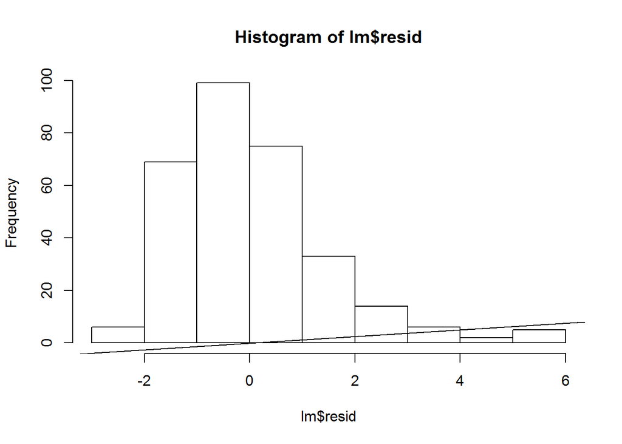

```
## [1] 1.21609
## attr(,"method")
## [1] "moment"
```

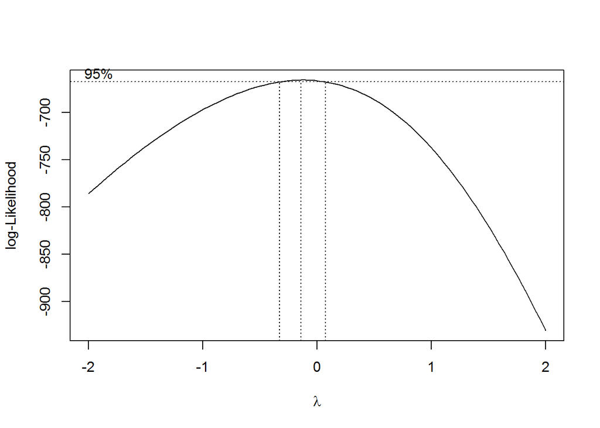

```
##              lamda       lik
##   [1,] -0.14141414 -665.7705
##   [2,] -0.10101010 -665.7794
##   [3,] -0.18181818 -665.9168
##   [4,] -0.06060606 -665.9472
##   [5,] -0.22222222 -666.2149
##   [6,] -0.02020202 -666.2773
##   [7,] -0.26262626 -666.6613
##   [8,]  0.02020202 -666.7733
##   [9,] -0.30303030 -667.2525
##  [10,]  0.06060606 -667.4385
##  [11,] -0.34343434 -667.9852
##  [12,]  0.10101010 -668.2764
##  [13,] -0.38383838 -668.8559
##  [14,]  0.14141414 -669.2904
```

[output cut: 86 more lines]

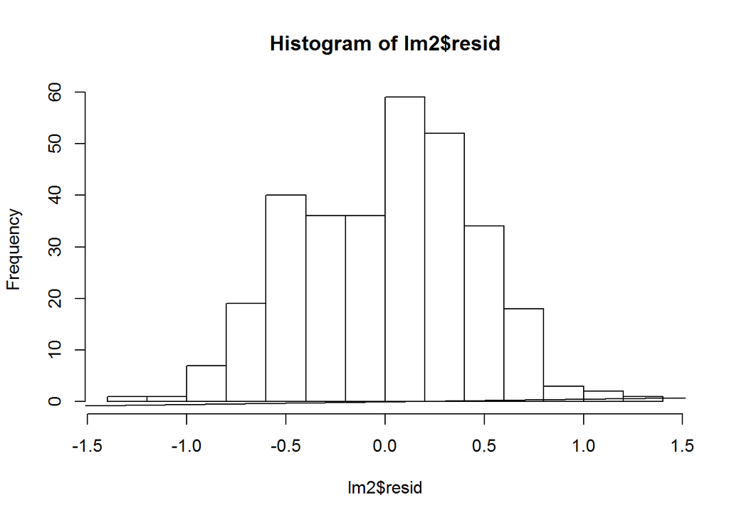

```
## [1] -0.09952942
## attr(,"method")
## [1] "moment"
```

```
##
##  studentized Breusch-Pagan test
##
## data:  lm2
## BP = 35.355, df = 13, p-value = 0.0007467
```

# Differently coded binary dependent variable (above or below median Donation)

```
## BelowEq Med Don   Above Med Don
##             196             158
```

```
##
##                   Control RecNos DefNos RecNap DefNap RecPol DefPol RecPar
##   BelowEq Med Don      16     20     24     17     15     13     17     16
##   Above Med Don        15     11     10     16     18     19     12     14
##
##                   DefPar RecKno DefKno
##   BelowEq Med Don     19     22     17
##   Above Med Don       15     11     17
```

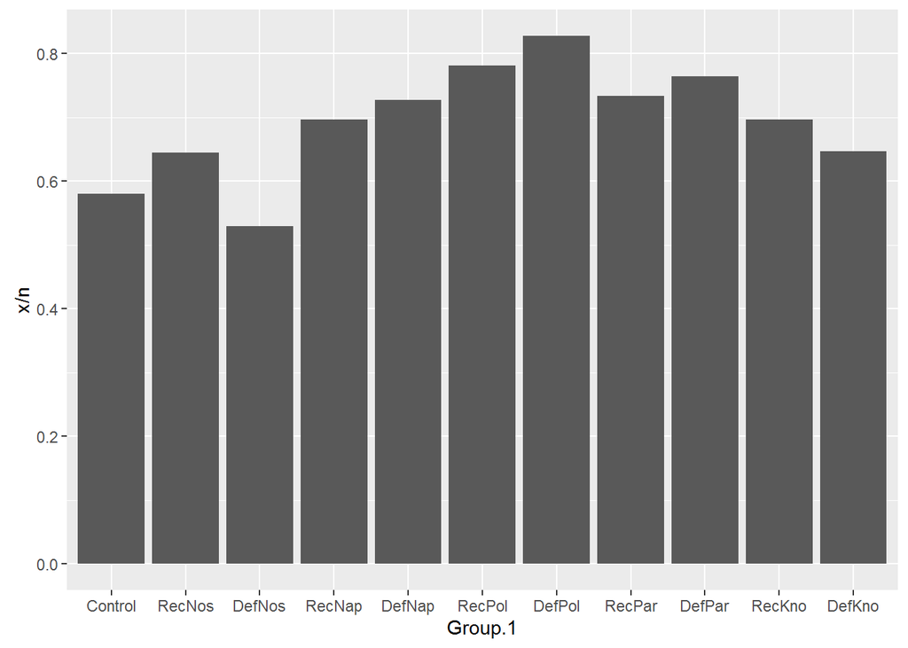

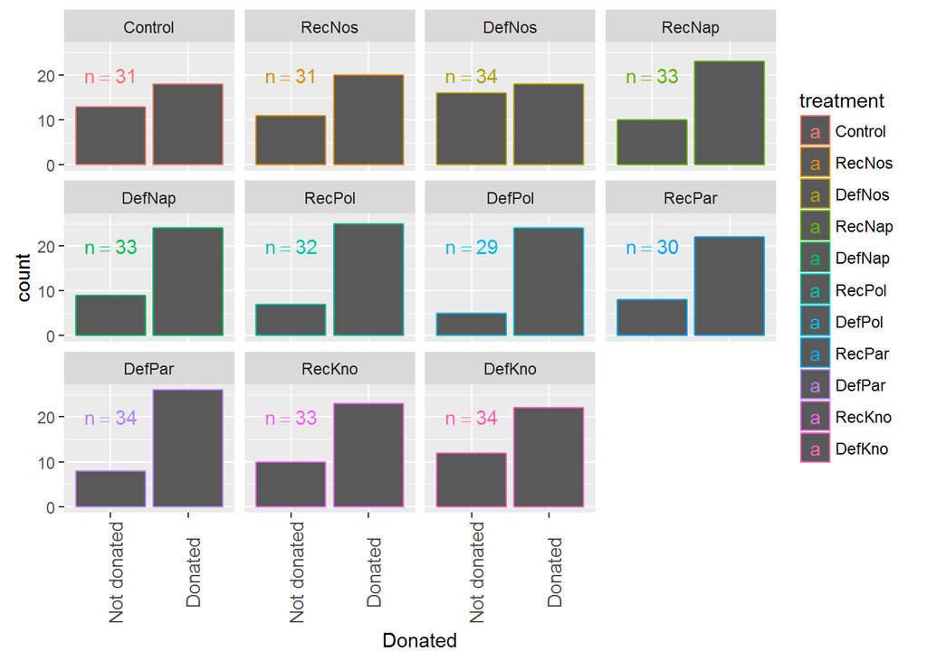

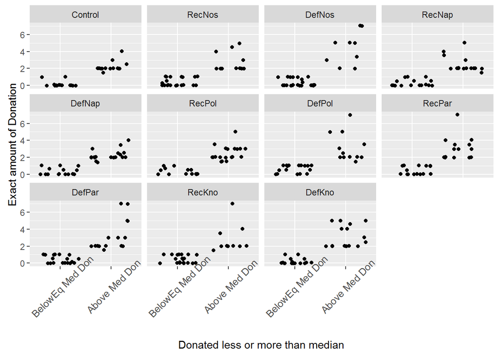

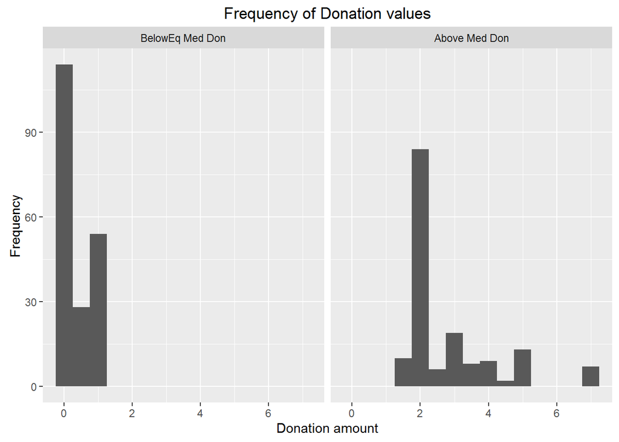

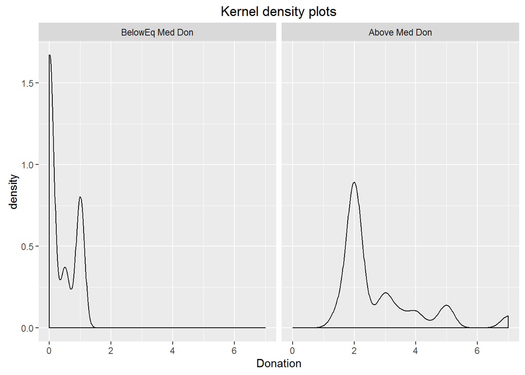

# Change dependent variable Donation to log(Donation+1)

```
## [1] 0.6931472
```

# Separate into two regressions (because bimodal): Logit then OLS (without zeros)

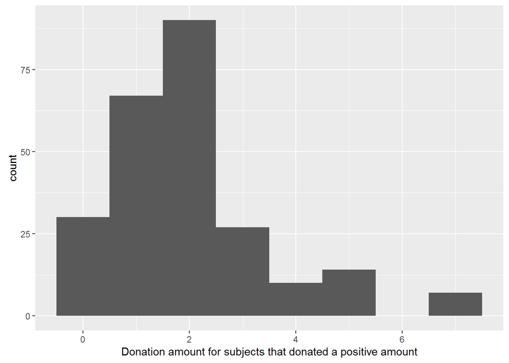

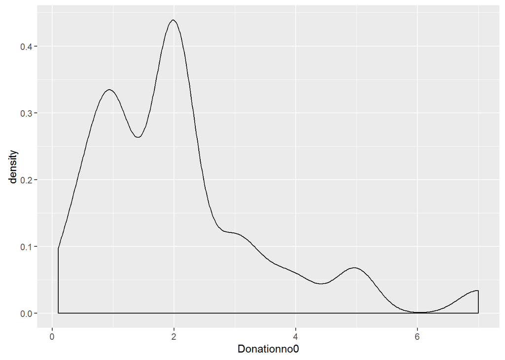

# All tests and descriptive statistics with Distance to 5 instead of Donation variable